# D208 Predictive Modeling

## Performance Assessment 2

### A1: Research Question

What combination of variables can best be used to predict churn?

### A2: Goal of Analysis

The purpose of this analysis is to discover if there is a set of variables that can be used to predict whether or not a customer will churn. This is important to the organization because it can be used to forecast future customer numbers and revenue. It can also lay the ground work for determining the cause of churn among certain customers and allow the organization to prepare strategies for improved customer retention.

### B1: Assumptions of Multiple Logistic Regression

1. The dependant variable is binary. This means that the dependent variable can only have two possible outcomes.
2. The observations used are independent. This means that the data used should not come from repeated measurements of the same individual or have any other relationship.
3. The independent variables are not highly correlated with one another.
4. There are no outliers that are so extreme as to overly influence the data.
5. There is a linear relationship between the explanatory variables and the logit of the dependent variable.
6. The sample size used is large enough for the number of explanatory variables used in the analysis (Bobbitt, 2020).

### B2: Benefits of Using Python

Python was chosen for this analysis due to its simple intuitive syntax and its host of easy to use packages that make linear regression simple to execute.

### B3: Justification for Using Logistic Regression to Answer Research Question

For this analysis, we are trying to create a model that will allow us to predict an outcome based on a set of observations. Logistic regression is being used because the outcome we are trying to predict is binary as opposed to linear regression which is used to try and predict a continuous numerical value.

### C1: Data Cleaning

The goal of data cleaning in this analysis is to check for null values and treat them, ensure that qualitative variables do not contain any typos that would create extra variables when performing one hot encoding, and to look for and assess outliers amongst the quantitative variables.

```python
# import packages for cleaning and analysis
import pandas as pd
import numpy as np
import matplotlib.pyplot as plt
import seaborn as sns
from statsmodels.formula.api import logit
from statsmodels.stats.outliers_influence import variance_inflation_factor
from patsy import dmatrices
# remove future warning messages [In-Text Citation: (Henley, 2023)]
import warnings
warnings.simplefilter(action='ignore', category=FutureWarning)
```

```python
# read in data set
# specified what values to read as null to prevent incorrect null values in internet service column
df = pd.read_csv("churn_clean.csv", na_values="NA", keep_default_na=False)
```

```python
# set column names to all lower case
df.columns = df.columns.str.lower()
```

```python
# create new dataframe only containing explanatory and dependent variables
exp_var = ['population', 'area', 'children', 'age', 'income', 'marital', 'gender',
          'outage_sec_perweek', 'email', 'contacts', 'yearly_equip_failure', 'contract',
          'internetservice', 'tenure', 'monthlycharge', 'bandwidth_gb_year', 'item1',
          'item2', 'item3', 'item4', 'item5', 'item6', 'item7', 'item8']

dep_var = 'churn'

churn = df[exp_var + [dep_var]]
```

Here I use the info method to quickly check to see if any null values can be found in the data. Since no obvious null values appear. No further action is needed.

```python
churn.info()
```

```
<class 'pandas.core.frame.DataFrame'>
RangeIndex: 10000 entries, 0 to 9999
Data columns (total 25 columns):
 #   Column                Non-Null Count  Dtype
---  ------                --------------  -----
 0   population            10000 non-null  int64
 1   area                  10000 non-null  object
 2   children              10000 non-null  int64
 3   age                   10000 non-null  int64
 4   income                10000 non-null  float64
 5   marital               10000 non-null  object
 6   gender                10000 non-null  object
 7   outage_sec_perweek    10000 non-null  float64
 8   email                 10000 non-null  int64
 9   contacts              10000 non-null  int64
```

[output cut: 17 more lines]

#### Check Qualitative Variables for Typos and Other Issues

I used the value counts method to see all the unique values for my qualitative variables and check for typos or other issues that may exist within the data. All of the output is good and no further action is needed.

```python
churn['churn'].value_counts()
```

```
churn
No     7350
Yes    2650
Name: count, dtype: int64
```

```python
churn['area'].value_counts()
```

```
area
Suburban    3346
Urban       3327
Rural       3327
Name: count, dtype: int64
```

```python
churn['marital'].value_counts()
```

```
marital
Divorced         2092
Widowed          2027
Separated        2014
Never Married    1956
Married          1911
Name: count, dtype: int64
```

```python
churn['gender'].value_counts()
```

```
gender
Female       5025
Male         4744
Nonbinary     231
Name: count, dtype: int64
```

```python
churn['contract'].value_counts()
```

```
contract
Month-to-month    5456
Two Year          2442
One year          2102
Name: count, dtype: int64
```

```python
churn['internetservice'].value_counts()
```

```
internetservice
Fiber Optic    4408
DSL            3463
None           2129
Name: count, dtype: int64
```

```python
churn['item1'].value_counts()
```

```
item1
3    3448
4    3358
2    1393
5    1359
1     224
6     199
7      19
Name: count, dtype: int64
```

```python
churn['item2'].value_counts()
```

```
item2
3    3415
4    3412
5    1368
2    1360
1     217
6     215
7      13
Name: count, dtype: int64
```

```python
churn['item3'].value_counts()
```

```
item3
3    3435
4    3410
2    1424
5    1313
6     203
1     202
7      12
8       1
Name: count, dtype: int64
```

```python
churn['item4'].value_counts()
```

```
item4
4    3452
3    3430
2    1350
5    1335
1     221
6     203
7       9
Name: count, dtype: int64
```

```python
churn['item5'].value_counts()
```

```
item5
3    3462
4    3417
2    1378
5    1321
1     206
6     204
7      12
Name: count, dtype: int64
```

```python
churn['item6'].value_counts()
```

```
item6
3    3445
4    3333
2    1427
5    1382
6     210
1     190
7      12
8       1
Name: count, dtype: int64
```

```python
churn['item7'].value_counts()
```

```
item7
4    3456
3    3446
5    1335
2    1309
6     224
1     219
7      11
Name: count, dtype: int64
```

```python
churn['item8'].value_counts()
```

```
item8
3    3461
4    3400
2    1378
5    1335
1     206
6     205
7      14
8       1
Name: count, dtype: int64
```

#### Generate Boxplots of Quantitative Variables to Check for Outliers

To assess my quantitative variables for outliers, I generated a boxplot for each variable and then used the length function and value counts method to determine the number of outliers. I chose not to treat any of the outliers except children and the reasoning for each variable can be found below.

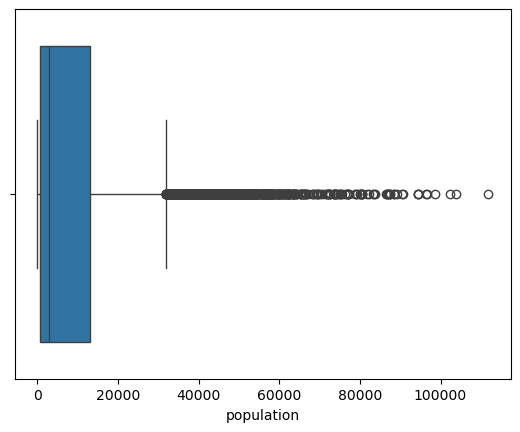

```python
sns.boxplot(data=churn, x='population')
```

```python
print('Number of Outliers:', len(churn.loc[churn['population']>30000, 'population']))
```

```
Number of Outliers: 1043
```

Roughly ten percent of the data set are outliers. However, the numbers are not completely unrealistic for people living in large cities. The outliers may simply be a result of having a large number of customers in rural towns and cities. The outliers will not be treated.

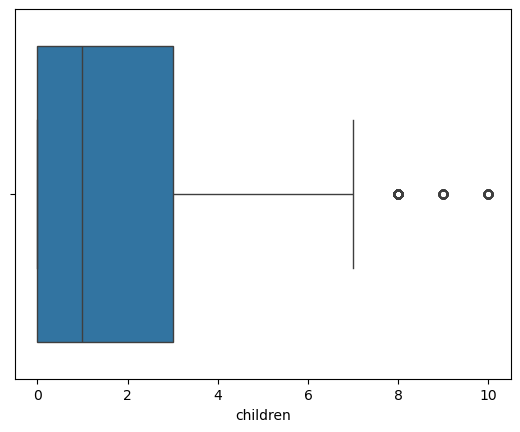

```python
sns.boxplot(data=churn, x='children')
```

```python
print('Number of Outliers:')
churn.loc[churn['children']>7, 'children'].value_counts()
```

```
Number of Outliers:
```

```
children
8     210
10     99
9      92
Name: count, dtype: int64
```

```python
# check outliers amongst younger people
churn.loc[(churn['children']>7)&(churn['age']<30), 'age'].value_counts()
```

```
age
19    10
24    10
23     9
18     9
29     8
25     7
26     7
20     7
22     7
27     5
21     4
28     3
Name: count, dtype: int64
```

```python
# impute younger outliers with the median for their age group
churn.loc[(churn['children']>7)&(churn['age']<30), 'children'] = churn.loc[(churn['children']<8)&(churn['age']<30), 'children'].median()
```

```python
# recheck for outliers amongst younger people
churn.loc[(churn['children']>7)&(churn['age']<30), 'age'].value_counts()
```

```
Series([], Name: count, dtype: int64)
```

Outliers for the children variable make up around four percent of the data set. Further investigation showed that some of these outliers were quite young for how many children they supposedly had. These values were deemed unrealistic and were imputed with the median number of children for their age group. The other outliers were left untreated since they do not represent an unrealistic number of children for someone over thirty and could be a significant observation for the data.

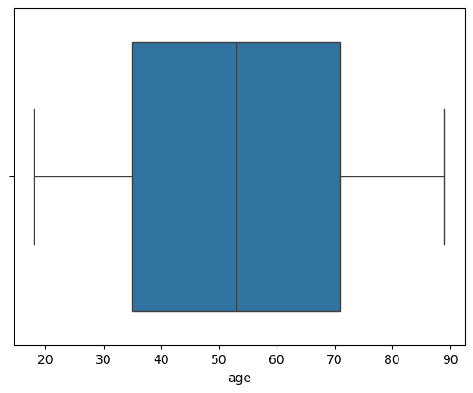

```python
sns.boxplot(data=churn, x='age')
```

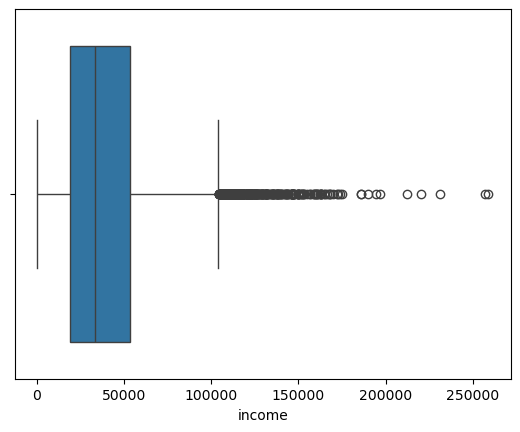

```python
sns.boxplot(data=churn, x='income')
```

```python
print('Number of Outliers:', len(churn.loc[churn['income']>100000, 'income']))
print('Number of Outliers over 150k:', len(churn.loc[churn['income']>150000, 'income']))
print('Number of Outliers over 200k:', len(churn.loc[churn['income']>200000, 'income']))
```

```
Number of Outliers: 395
Number of Outliers over 150k: 45
Number of Outliers over 200k: 5
```

The outliers for income account for just under four percent of the data set. Those at the highest end make up less than half a percent of the data. The income of these individuals is not unreasonably high and I will not change them to preserve the integrity of the data.

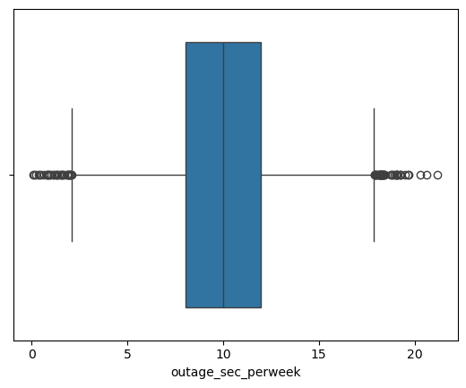

```python
sns.boxplot(data=churn, x='outage_sec_perweek')
```

```python
print('Lower Outliers:', len(churn[churn['outage_sec_perweek']<2.5]))
print('Upper Outliers:', len(churn[churn['outage_sec_perweek']>18]))
```

```
Lower Outliers: 59
Upper Outliers: 37
```

Outliers represent less than one percent of the whole data set and could be an important observation that influences churn. The outliers will not be treated.

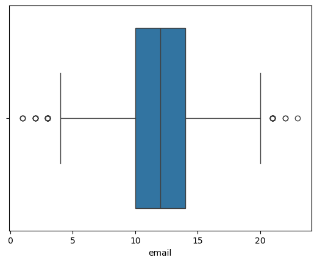

```python
sns.boxplot(data=churn, x='email')
```

```python
print('Lower Outliers:', len(churn[churn['email']<4]))
print('Upper Outliers:', len(churn[churn['email']>20]))
```

```
Lower Outliers: 23
Upper Outliers: 15
```

Not a significant number of outliers and they do not fall too far from the rest of the data. The outliers will not be treated.

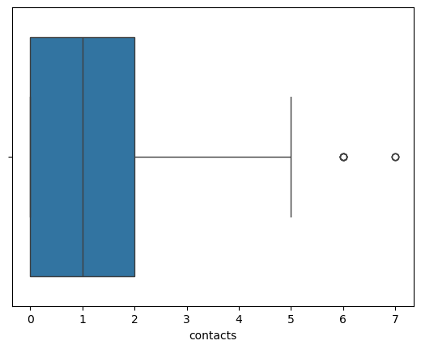

```python
sns.boxplot(data=churn, x='contacts')
```

```python
print('Number of outliers:', len(churn[churn['contacts']>5]))
```

```
Number of outliers: 8
```

Number of outliers is not significant enough to distort the data and will not be treated.

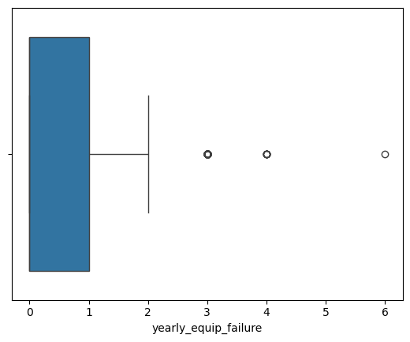

```python
sns.boxplot(data=churn, x='yearly_equip_failure')
```

```python
print('Number of Outliers:',len(churn[churn['yearly_equip_failure']>2]))
```

```
Number of Outliers: 94
```

The number of outliers is less than one percent of the data set and could represent an important insight into the data. Therefore, the outliers will not be treated.

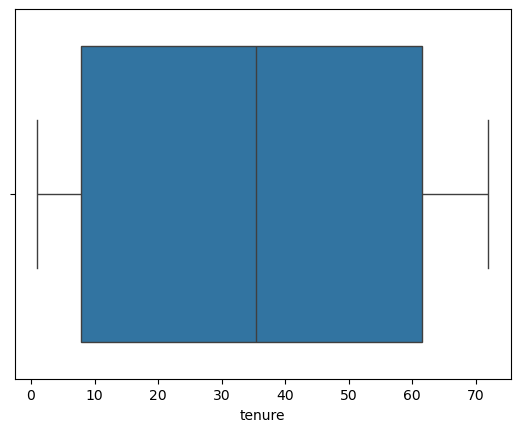

```python
sns.boxplot(data=churn, x='tenure')
```

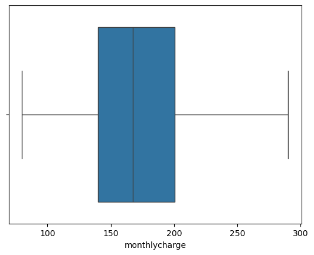

```python
sns.boxplot(data=churn, x='monthlycharge')
```

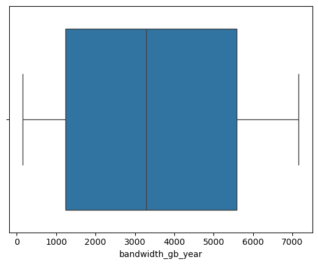

```python
sns.boxplot(data=churn, x='bandwidth_gb_year')
```

### C2: Summary Statistics

#### Statistics for Dependent Variable

```python
print('Summary Statistics for Churn:')
churn['churn'].describe()
```

```
Summary Statistics for Churn:
```

```
count     10000
unique        2
top          No
freq       7350
Name: churn, dtype: object
```

#### Summary Statistics for Qualitative Variables

##### Area

The variable area contains three unique values with "Suburban" being the mode with 3346 values.

```python
churn['area'].describe()
```

```
count        10000
unique           3
top       Suburban
freq          3346
Name: area, dtype: object
```

##### Marital

The variable marital contains five unique values with "Divorced" being the mode with 2092 values.

```python
churn['marital'].describe()
```

```
count        10000
unique           5
top       Divorced
freq          2092
Name: marital, dtype: object
```

##### Gender

The variable gender contains three unique values with "Female" being the mode with 5025 values.

```python
churn['gender'].describe()
```

```
count      10000
unique         3
top       Female
freq        5025
Name: gender, dtype: object
```

##### Contract

The variable contract contains three unique values with "Month-to-month" being the mode with 5456 values.

```python
churn['contract'].describe()
```

```
count              10000
unique                 3
top       Month-to-month
freq                5456
Name: contract, dtype: object
```

##### Internet Service

The variable internetservice contains three unique values with "Fiber Optic" being the mode with 4408 values.

```python
churn['internetservice'].describe()
```

```
count           10000
unique              3
top       Fiber Optic
freq             4408
Name: internetservice, dtype: object
```

##### Item 1

The variable item1 contains seven unique values with "3" being the mode with 3448 values.

```python
churn['item1'].value_counts().sort_values(ascending=False)
```

```
item1
3    3448
4    3358
2    1393
5    1359
1     224
6     199
7      19
Name: count, dtype: int64
```

##### Item 2

The variable item2 contains seven unique values with "3" being the mode with 3415 values.

```python
churn['item2'].value_counts().sort_values(ascending=False)
```

```
item2
3    3415
4    3412
5    1368
2    1360
1     217
6     215
7      13
Name: count, dtype: int64
```

##### Item 3

The variable item3 contains eight unique values with "3" being the mode with 3435 values.

```python
churn['item3'].value_counts().sort_values(ascending=False)
```

```
item3
3    3435
4    3410
2    1424
5    1313
6     203
1     202
7      12
8       1
Name: count, dtype: int64
```

##### Item 4

The variable item4 contains seven unique values with "4" being the mode with 3452 values.

```python
churn['item4'].value_counts().sort_values(ascending=False)
```

```
item4
4    3452
3    3430
2    1350
5    1335
1     221
6     203
7       9
Name: count, dtype: int64
```

##### Item 5

The variable item5 contains seven unique values with "3" being the mode with 3462 values.

```python
churn['item5'].value_counts().sort_values(ascending=False)
```

```
item5
3    3462
4    3417
2    1378
5    1321
1     206
6     204
7      12
Name: count, dtype: int64
```

##### Item 6

The variable item6 contains eight unique values with "3" being the mode with 3445 values.

```python
churn['item6'].value_counts().sort_values(ascending=False)
```

```
item6
3    3445
4    3333
2    1427
5    1382
6     210
1     190
7      12
8       1
Name: count, dtype: int64
```

##### Item 7

The variable item7 contains seven unique values with "4" being the mode with 3456 values.

```python
churn['item7'].value_counts().sort_values(ascending=False)
```

```
item7
4    3456
3    3446
5    1335
2    1309
6     224
1     219
7      11
Name: count, dtype: int64
```

##### Item 8

The variable item8 contains eight unique values with "3" being the mode with 3461 values.

```python
churn['item8'].value_counts().sort_values(ascending=False)
```

```
item8
3    3461
4    3400
2    1378
5    1335
1     206
6     205
7      14
8       1
Name: count, dtype: int64
```

#### Summary Statistics for Quantitative Variables

##### Population

The population variable has a mean of 9756 with a standard deivation of 14432. The minimum and maximum values are 0 and 111850 respectively. The data is right skewed which can be seen in the shape of the histogram in section C3.

```python
churn['population'].describe()
```

```
count     10000.000000
mean       9756.562400
std       14432.698671
min           0.000000
25%         738.000000
50%        2910.500000
75%       13168.000000
max      111850.000000
Name: population, dtype: float64
```

##### Children

The children variable has a mean of 2.021 with a standard deivation of 2.057. The minimum and maximum values are 0 and 10 respectively. The data is right skewed which can be seen in the shape of the histogram in section C3.

```python
churn['children'].describe()
```

```
count    10000.000000
mean         2.021500
std          2.057732
min          0.000000
25%          0.000000
50%          1.000000
75%          3.000000
max         10.000000
Name: children, dtype: float64
```

##### Age

The age variable has a mean of 53.0784 with a standard deivation of 20.6988. The minimum and maximum values are 18 and 89 respectively. The data is distributed uniformly which can be seen in the shape of the histogram in section C3.

```python
churn['age'].describe()
```

```
count    10000.000000
mean        53.078400
std         20.698882
min         18.000000
25%         35.000000
50%         53.000000
75%         71.000000
max         89.000000
Name: age, dtype: float64
```

##### Income

The income variable has a mean of 39806 with a standard deivation of 28199. The minimum and maximum values are 348 and 258900 respectively. The data is right skewed which can be seen in the shape of the histogram in section C3.

```python
churn['income'].describe()
```

```
count     10000.000000
mean      39806.926771
std       28199.916702
min         348.670000
25%       19224.717500
50%       33170.605000
75%       53246.170000
max      258900.700000
Name: income, dtype: float64
```

##### Outage Seconds Per Week

The outage_sec_perweek variable has a mean of 10.0018 with a standard deivation of 2.9760. The minimum and maximum values are 0.0997 and 21.2072 respectively. The data is distributed normally which can be seen in the shape of the histogram in section C3.

```python
churn['outage_sec_perweek'].describe()
```

```
count    10000.000000
mean        10.001848
std          2.976019
min          0.099747
25%          8.018214
50%         10.018560
75%         11.969485
max         21.207230
Name: outage_sec_perweek, dtype: float64
```

##### Email

The email variable has a mean of 12.0160 with a standard deivation of 3.0258. The minimum and maximum values are 1 and 23 respectively. The data is distributed normally which can be seen in the shape of the histogram in section C3.

```python
churn['email'].describe()
```

```
count    10000.000000
mean        12.016000
std          3.025898
min          1.000000
25%         10.000000
50%         12.000000
75%         14.000000
max         23.000000
Name: email, dtype: float64
```

##### Contacts

The contacts variable has a mean of 0.9942 with a standard deivation of 0.9884. The minimum and maximum values are 0 and 7 respectively. The data is right skewed which can be seen in the shape of the histogram in section C3.

```python
churn['contacts'].describe()
```

```
count    10000.000000
mean         0.994200
std          0.988466
min          0.000000
25%          0.000000
50%          1.000000
75%          2.000000
max          7.000000
Name: contacts, dtype: float64
```

##### Yearly Equipment Failure

The yearly_equip_failure variable has a mean of 0.3980 with a standard deivation of 0.6359. The minimum and maximum values are 0 and 6 respectively. The data is right skewed which can be seen in the shape of the histogram in section C3.

```python
churn['yearly_equip_failure'].describe()
```

```
count    10000.000000
mean         0.398000
std          0.635953
min          0.000000
25%          0.000000
50%          0.000000
75%          1.000000
max          6.000000
Name: yearly_equip_failure, dtype: float64
```

##### Tenure

The tenure variable has a mean of 34.5261 with a standard deivation of 26.4430. The minimum and maximum values are 1.0002 and 71.9992 respectively. The data follows a bi-modal distribution which can be seen in the shape of the histogram in section C3.

```python
churn['tenure'].describe()
```

```
count    10000.000000
mean        34.526188
std         26.443063
min          1.000259
25%          7.917694
50%         35.430507
75%         61.479795
max         71.999280
Name: tenure, dtype: float64
```

##### Monthly Charge

The monthlycharge variable has a mean of 172.6248 with a standard deivation of 42.9430. The minimum and maximum values are 79.9788 and 290.1604 respectively. The data follows a normal distribution which can be seen in the shape of the histogram in section C3.

```python
churn['monthlycharge'].describe()
```

```
count    10000.000000
mean       172.624816
std         42.943094
min         79.978860
25%        139.979239
50%        167.484700
75%        200.734725
max        290.160419
Name: monthlycharge, dtype: float64
```

##### Bandwidth GB Year

```python
churn['bandwidth_gb_year'].describe()
```

```
count    10000.000000
mean      3392.341550
std       2185.294852
min        155.506715
25%       1236.470827
50%       3279.536903
75%       5586.141370
max       7158.981530
Name: bandwidth_gb_year, dtype: float64
```

### C3: Univariate and Bivariate Statistics

##### Area

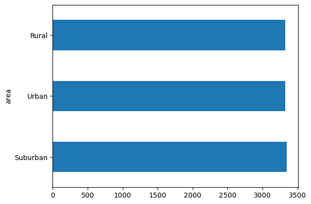

```python
# univariate
churn['area'].value_counts().plot(kind='barh')
```

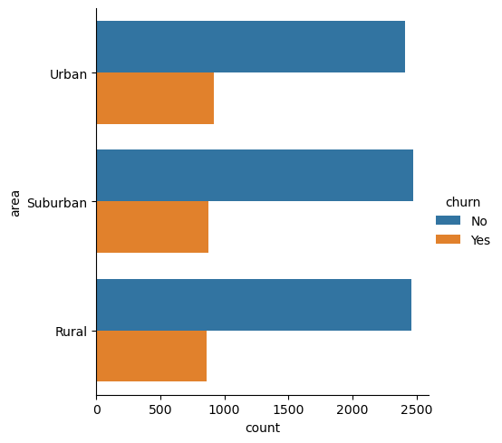

```python
# bivariate
sns.catplot(data=churn, y='area', hue='churn', kind='count')
```

##### Marital

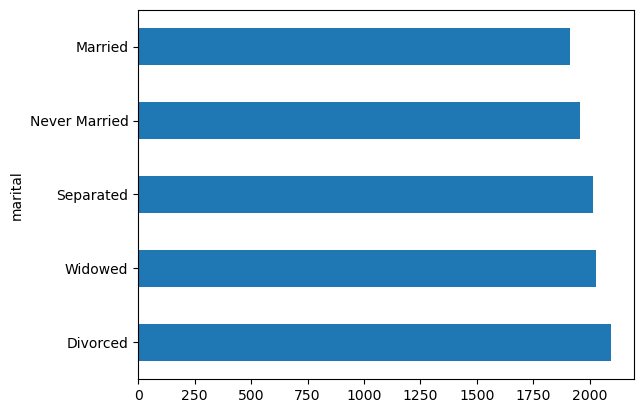

```python
#univariate
churn['marital'].value_counts().plot(kind='barh')
```

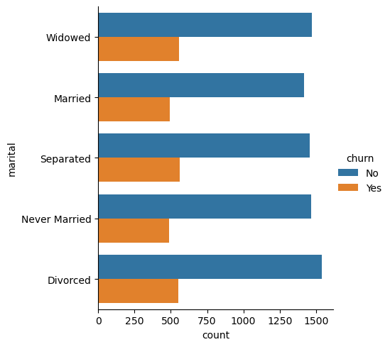

```python
#bivariate
sns.catplot(data=churn, y='marital', hue='churn', kind='count')
```

##### Gender

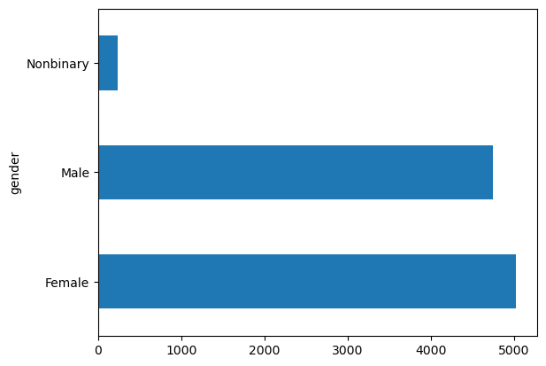

```python
# univariate
churn['gender'].value_counts().plot(kind='barh')
```

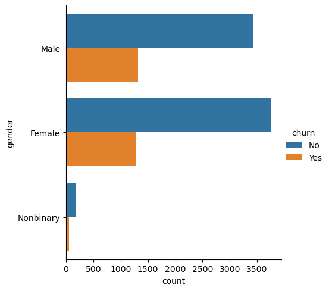

```python
#bivariate
sns.catplot(data=churn, y='gender', hue='churn', kind='count')
```

##### Contract

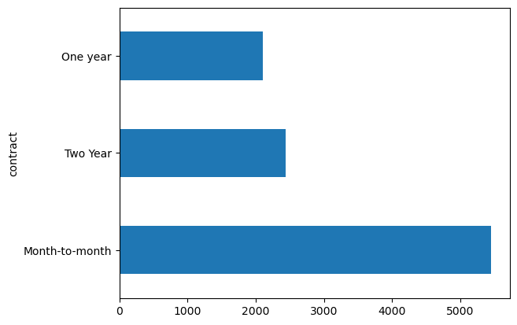

```python
# univariate
churn['contract'].value_counts().plot(kind='barh')
```

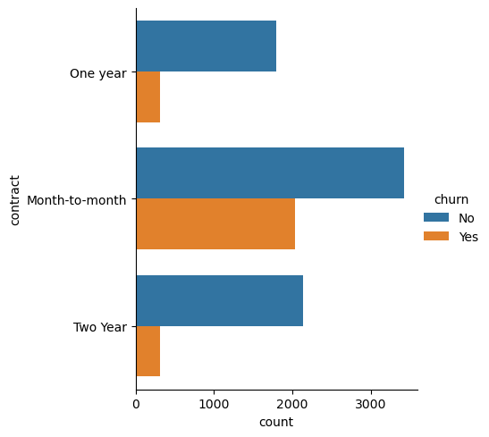

```python
# bivariate
sns.catplot(data=churn, y='contract', hue='churn', kind='count')
```

##### Internet Service

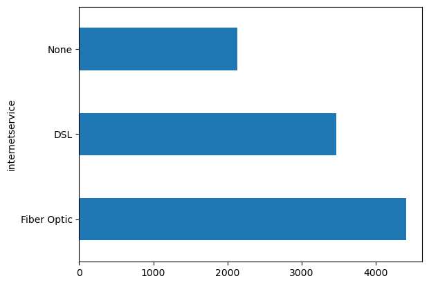

```python
# univariate
churn['internetservice'].value_counts().plot(kind='barh')
```

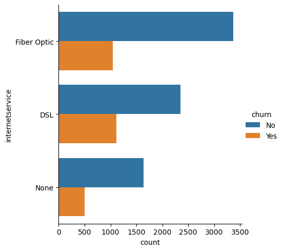

```python
# bivariate
sns.catplot(data=churn, y='internetservice', hue='churn', kind='count')
```

##### Item 1

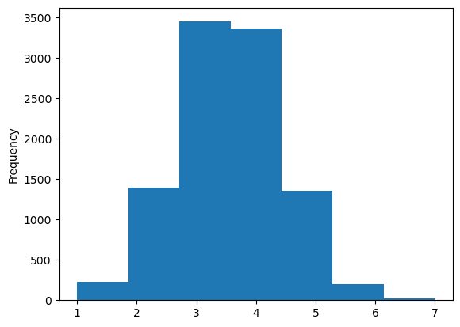

```python
# univariate
churn['item1'].plot(kind='hist', bins=7)
```

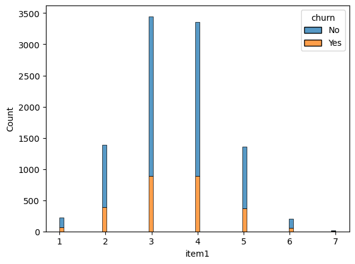

```python
# bivariate
sns.histplot(data=churn, x='item1', hue='churn', multiple='stack')
```

##### Item 2

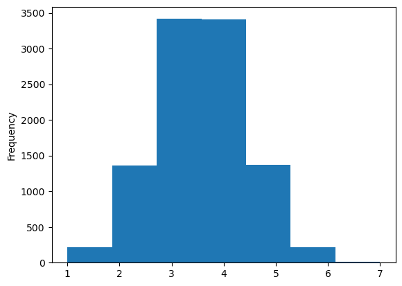

```python
# univariate
churn['item2'].plot(kind='hist', bins=7)
```

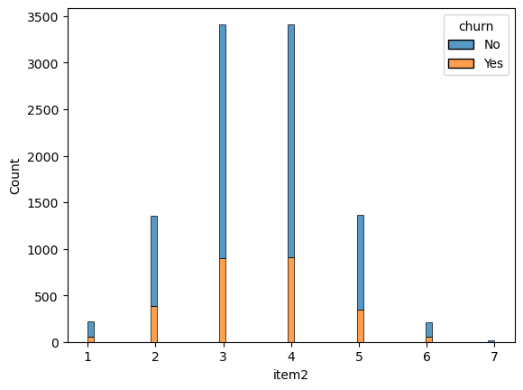

```python
# bivariate
sns.histplot(data=churn, x='item2', hue='churn', multiple='stack')
```

##### Item 3

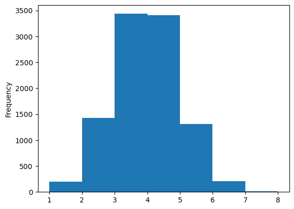

```python
# univariate
churn['item3'].plot(kind='hist', bins=7)
```

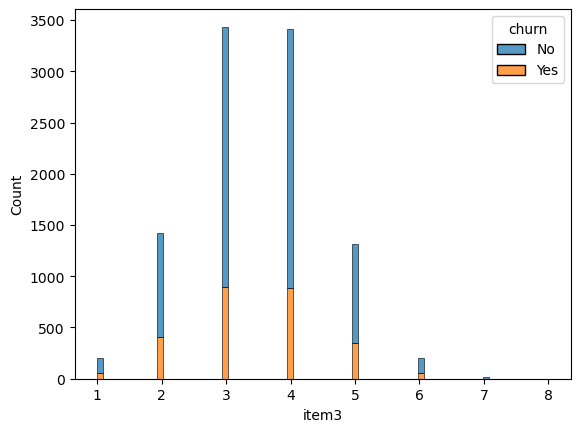

```python
# bivariate
sns.histplot(data=churn, x='item3', hue='churn', multiple='stack')
```

##### Item 4

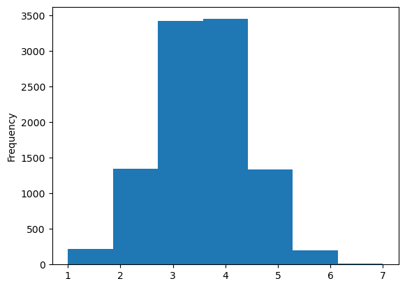

```python
# univariate
churn['item4'].plot(kind='hist', bins=7)
```

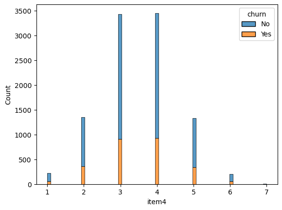

```python
# bivariate
sns.histplot(data=churn, x='item4', hue='churn', multiple='stack')
```

##### Item 5

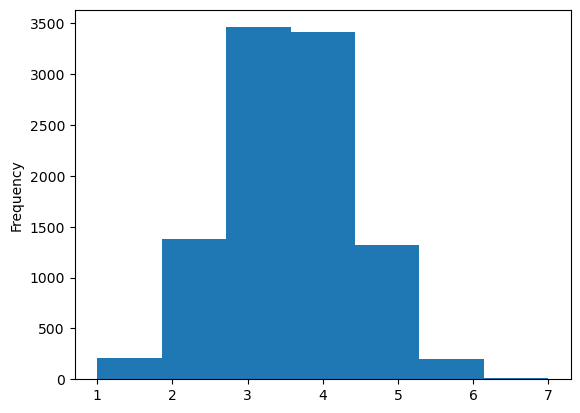

```python
# univariate
churn['item5'].plot(kind='hist', bins=7)
```

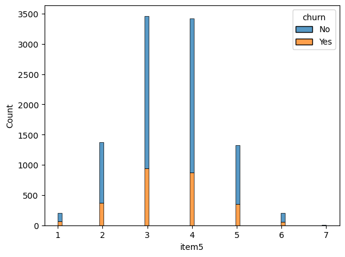

```python
#bivariate
sns.histplot(data=churn, x='item5', hue='churn', multiple='stack')
```

##### Item 6

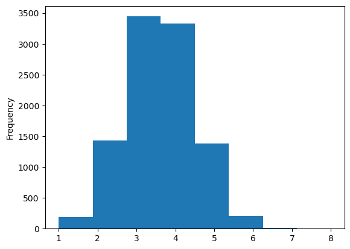

```python
# univariate
churn['item6'].plot(kind='hist', bins=8)
```

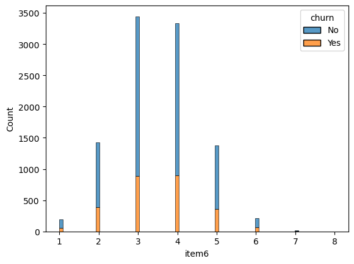

```python
# bivariate
sns.histplot(data=churn, x='item6', hue='churn', multiple='stack')
```

##### Item 7

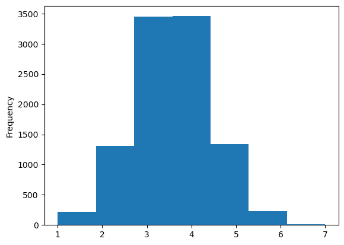

```python
# univariate
churn['item7'].plot(kind='hist', bins=7)
```

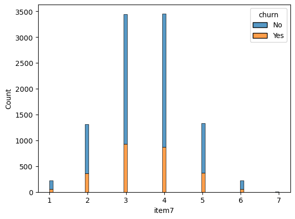

```python
# bivariate
sns.histplot(data=churn, x='item7', hue='churn', multiple='stack')
```

##### Item 8

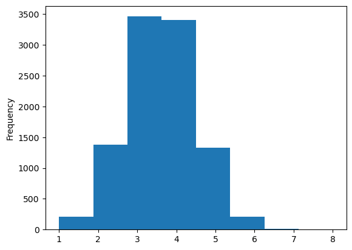

```python
# univariate
churn['item8'].plot(kind='hist', bins=8)
```

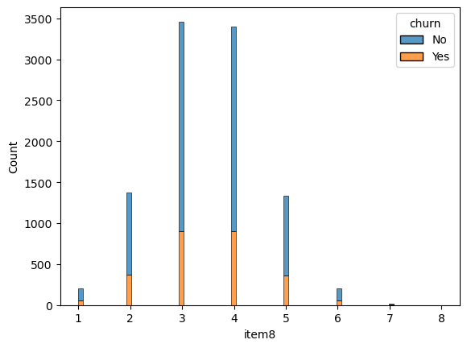

```python
# bivariate
sns.histplot(data=churn, x='item8', hue='churn', multiple='stack')
```

##### Population

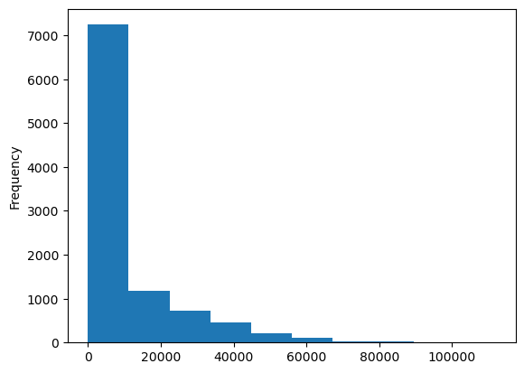

```python
# univariate
churn['population'].plot(kind='hist')
```

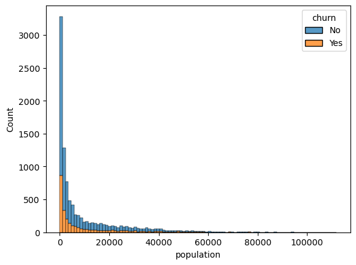

```python
# bivariate
sns.histplot(data=churn, x='population', hue='churn', multiple='stack')
```

##### Children

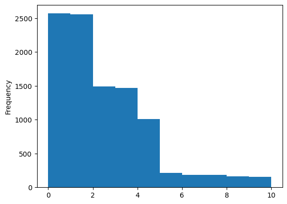

```python
# univariate
churn['children'].plot(kind='hist')
```

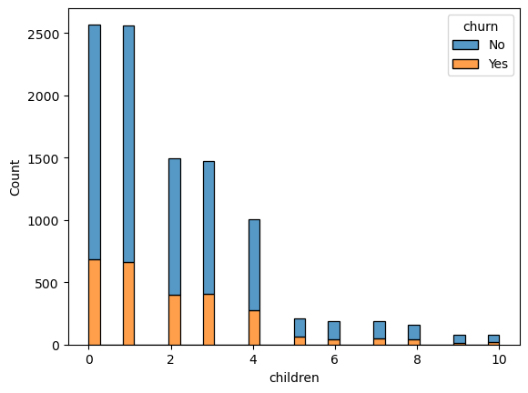

```python
# bivariate
sns.histplot(data=churn, x='children', hue='churn', multiple='stack')
```

##### Age

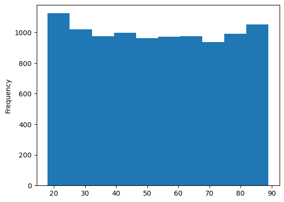

```python
#univariate
churn['age'].plot(kind='hist')
```

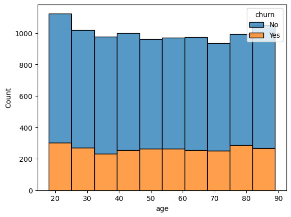

```python
# bivariate
sns.histplot(data=churn, x='age', hue='churn', multiple='stack', bins=10)
```

##### Income

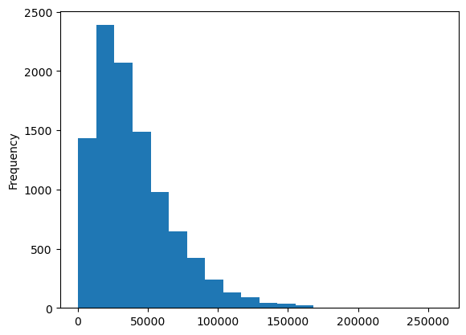

```python
# univariate
churn['income'].plot(kind='hist', bins=20)
```

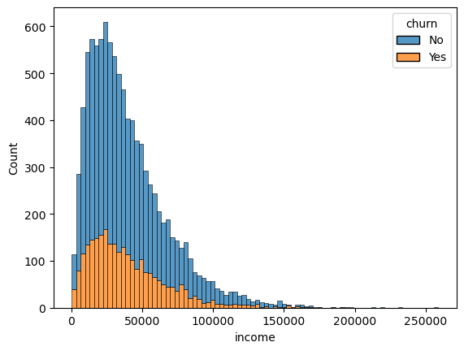

```python
# bivrariate
sns.histplot(data=churn, x='income', hue='churn', multiple='stack')
```

##### Outage Sec Per Week

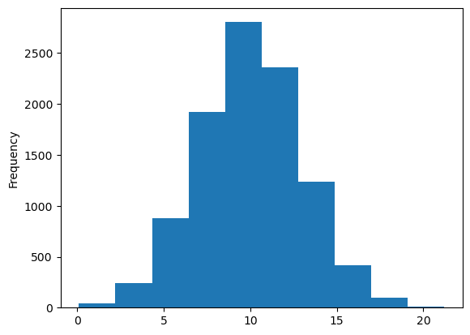

```python
# univariate
churn['outage_sec_perweek'].plot(kind='hist')
```

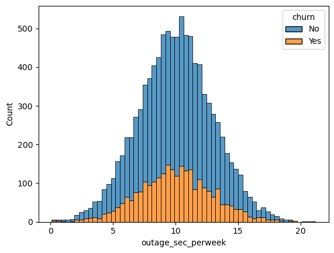

```python
# bivariate
sns.histplot(data=churn, x='outage_sec_perweek', hue='churn', multiple='stack')
```

##### Email

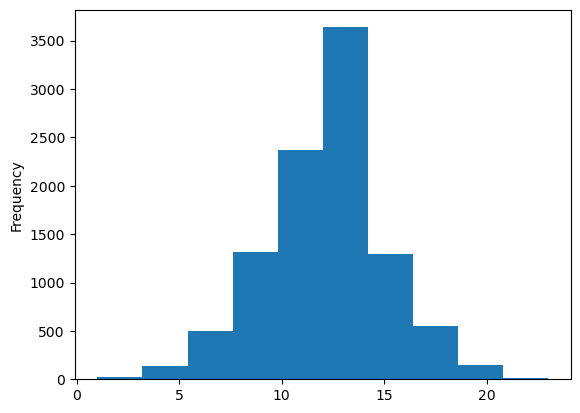

```python
# univariate
churn['email'].plot(kind='hist')
```

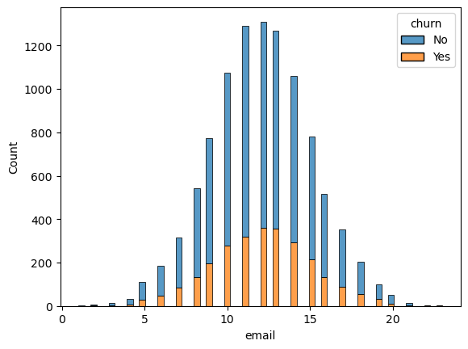

```python
# bivariate
sns.histplot(data=churn, x='email', hue='churn', multiple='stack')
```

##### Contacts

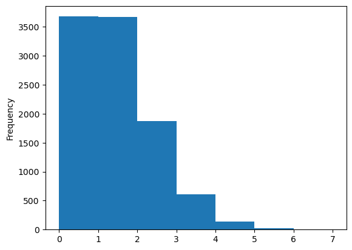

```python
# univariate
churn['contacts'].plot(kind='hist', bins=7)
```

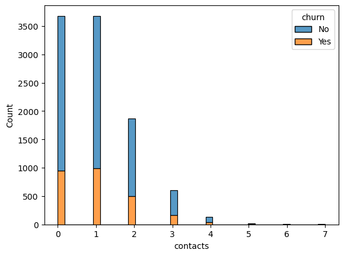

```python
# bivariate
sns.histplot(data=churn, x='contacts', hue='churn', multiple='stack')
```

##### Yearly Equipment Failure

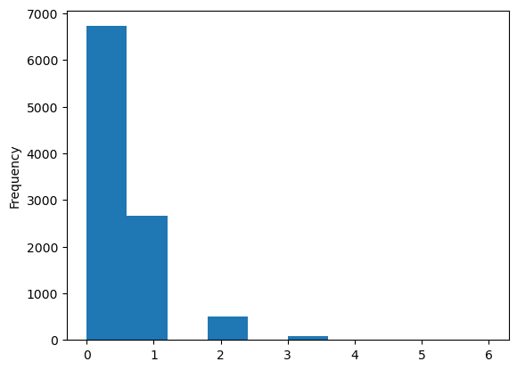

```python
# univariate
churn['yearly_equip_failure'].plot(kind='hist')
```

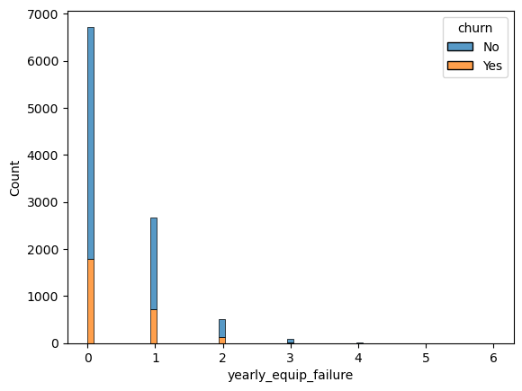

```python
# bivariate
sns.histplot(data=churn, x='yearly_equip_failure', hue='churn', multiple='stack')
```

##### Tenure

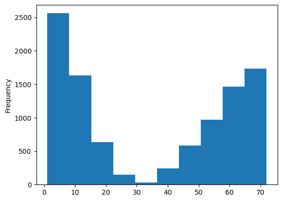

```python
# univariate
churn['tenure'].plot(kind='hist')
```

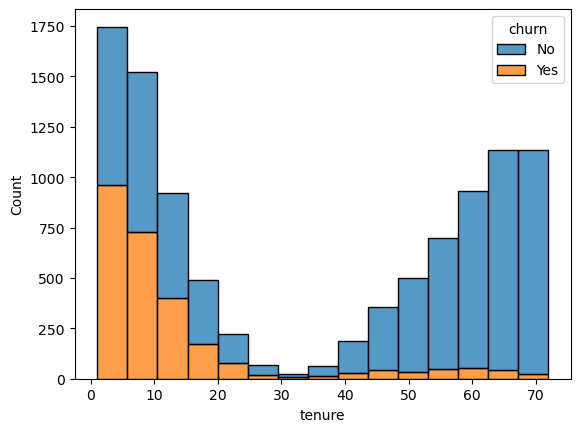

```python
# bivariate
sns.histplot(data=churn, x='tenure', hue='churn', multiple='stack')
```

##### Monthly Charge

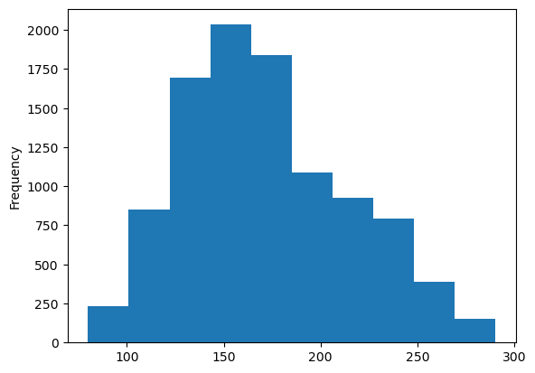

```python
churn['monthlycharge'].plot(kind='hist')
```

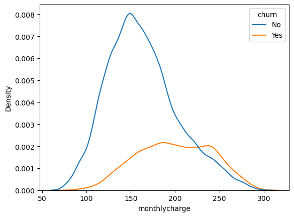

```python
# bivariate
sns.kdeplot(data=churn, x='monthlycharge', hue='churn')
```

##### Bandwidth GB Year

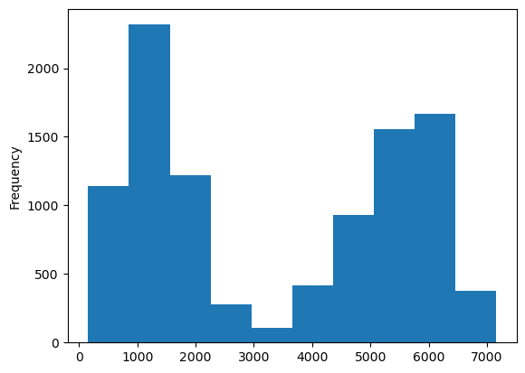

```python
# univariate
churn['bandwidth_gb_year'].plot(kind='hist')
```

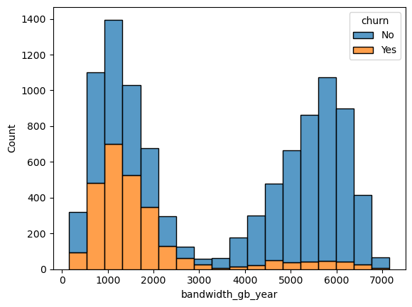

```python
sns.histplot(data=churn, x='bandwidth_gb_year', hue='churn', multiple='stack')
```

### C4: Data Transformation

The following steps were taken to prepare the data for analysis. First, I changed the values of the dependent variable to be 1 or 0. Then, the strings in the qualitative variables were adjusted to prepare them for one hot encoding. Then, I created dummy variables using the pandas get dummies function with drop first set to true so that one fewer dummy variable was produced than the number of unique values in the original column. This was done to prevent multicollinearity amongst the variables. Having dummy variables for every unique value produces multicollinearity because the value for one dummy in a certain row can be inferred based on the values of the other dummies. Then I calculated the VIF scores for my variables to check for multicollinearity amongst all of the variables and dropped any variables that had high scores.

```python
# change churn variable to contain 1 or 0
churn.loc[:,'churn'] = churn.loc[:,'churn'].replace(['Yes', 'No'], ['1', '0'])

churn['churn'].value_counts()
```

```
churn
0    7350
1    2650
Name: count, dtype: int64
```

```python
# prep qualitative variables for making dummy variables
for_dummy = ['area', 'marital', 'gender', 'contract', 'internetservice']

for var in for_dummy:
    churn.loc[:,var] = churn.loc[:,var].str.replace(' ', '_').str.replace('-','_').str.lower()
```

```python
# create dummy variables for non-numerical qualitative variabels
# drop_first set to True to avoid multicollinearity between dummy variables
churn_dummy = pd.get_dummies(churn, prefix=for_dummy, columns=for_dummy, drop_first=True, dtype=int)
churn_dummy.info()
```

```
<class 'pandas.core.frame.DataFrame'>
RangeIndex: 10000 entries, 0 to 9999
Data columns (total 32 columns):
 #   Column                       Non-Null Count  Dtype
---  ------                       --------------  -----
 0   population                   10000 non-null  int64
 1   children                     10000 non-null  int64
 2   age                          10000 non-null  int64
 3   income                       10000 non-null  float64
 4   outage_sec_perweek           10000 non-null  float64
 5   email                        10000 non-null  int64
 6   contacts                     10000 non-null  int64
 7   yearly_equip_failure         10000 non-null  int64
 8   tenure                       10000 non-null  float64
 9   monthlycharge                10000 non-null  float64
```

[output cut: 24 more lines]

```python
# convert churn column to integer data type
churn_dummy['churn'] = churn_dummy['churn'].astype(int)
```

```python
# check for multicollinearity amongst independent variables [In-Text Citation: (Bobbitt, 2020)]
formula = '''churn ~ population + children + age + income + outage_sec_perweek + email + contacts + yearly_equip_failure
                + tenure + monthlycharge + bandwidth_gb_year + item1 + item2 + item3 + item4 + item5 + item6 + item7 + item8
                + area_suburban + area_urban + marital_never_married + marital_separated + marital_widowed + gender_male
                + gender_nonbinary + contract_one_year + contract_two_year + internetservice_fiber_optic + internetservice_none
                + marital_married'''

y, X = dmatrices(formula, data=churn_dummy, return_type='dataframe')
vif=pd.DataFrame()
vif['VIF'] = [variance_inflation_factor(X.values, i) for i in range(X.shape[1])]
vif['variable'] = X.columns
print(vif.sort_values('VIF', ascending=False).head())
```

```
            VIF                     variable
11  1159.367570            bandwidth_gb_year
9   1140.954420                       tenure
0    156.781694                    Intercept
29    15.920811  internetservice_fiber_optic
10     8.571424                monthlycharge
```

```python
# drop bandwidth_gb_year due to high VIF
churn_dummy.drop(columns='bandwidth_gb_year', axis=1, inplace=True)
```

```python
# recheck vif scores
formula = '''churn ~ population + children + age + income + outage_sec_perweek + email + contacts + yearly_equip_failure
                + tenure + monthlycharge + item1 + item2 + item3 + item4 + item5 + item6 + item7 + item8
                + area_suburban + area_urban + marital_never_married + marital_separated + marital_widowed + gender_male
                + gender_nonbinary + contract_one_year + contract_two_year + internetservice_fiber_optic + internetservice_none
                + marital_married'''

y, X = dmatrices(formula, data=churn_dummy, return_type='dataframe')
vif=pd.DataFrame()
vif['VIF'] = [variance_inflation_factor(X.values, i) for i in range(X.shape[1])]
vif['variable'] = X.columns
print(vif.sort_values('VIF', ascending=False).head())
```

```
           VIF         variable
0   141.876779        Intercept
11    2.213154            item1
12    1.929599            item2
13    1.606364            item3
23    1.576192  marital_widowed
```

```python
# create copy for anaylsis
churn_ready = churn_dummy.copy()
```

### C5: Prepared Data Set

```python
# export analysis ready csv
# code commented out to prevent creating multiple copies
#churn_ready.to_csv(r'C:\Users\caleb\Documents\WGU\D208\churn_ready_jantsch_task2.csv')
```

### D1: Initial Model

```python
# define formula for initial model
formula_v1 = '''churn ~ population + children + age + income + outage_sec_perweek + email + contacts + yearly_equip_failure
                + tenure + monthlycharge + item1 + item2 + item3 + item4 + item5 + item6 + item7 + item8
                + area_suburban + area_urban + marital_never_married + marital_separated + marital_widowed + gender_male
                + gender_nonbinary + contract_one_year + contract_two_year + internetservice_fiber_optic + internetservice_none
                + marital_married'''

model_v1 = logit(formula_v1, data=churn_ready).fit()
print(model_v1.summary())
print('AIC:', model_v1.aic)
```

```
Optimization terminated successfully.
         Current function value: 0.233768
         Iterations 9
                           Logit Regression Results
==============================================================================
Dep. Variable:                  churn   No. Observations:                10000
Model:                          Logit   Df Residuals:                     9969
Method:                           MLE   Df Model:                           30
Date:                Fri, 12 Jul 2024   Pseudo R-squ.:                  0.5957
Time:                        11:34:02   Log-Likelihood:                -2337.7
converged:                       True   LL-Null:                       -5782.2
Covariance Type:            nonrobust   LLR p-value:                     0.000
===============================================================================================
                                  coef    std err          z      P>|z|      [0.025      0.975]
-----------------------------------------------------------------------------------------------
Intercept                      -5.9092      0.456    -12.971      0.000      -6.802      -5.016
population                   -1.31e-06   2.61e-06     -0.502      0.616   -6.43e-06     3.8e-06
children                        0.0140      0.018      0.767      0.443      -0.022       0.050
age                             0.0003      0.002      0.181      0.856      -0.003       0.004
income                       5.427e-07   1.31e-06      0.413      0.680   -2.03e-06    3.12e-06
outage_sec_perweek             -0.0004      0.012     -0.033      0.974      -0.025       0.024
email                          -0.0079      0.012     -0.647      0.518      -0.032       0.016
contacts                        0.0641      0.037      1.718      0.086      -0.009       0.137
yearly_equip_failure           -0.0229      0.059     -0.391      0.696      -0.138       0.092
tenure                         -0.1080      0.003    -39.920      0.000      -0.113      -0.103
monthlycharge                   0.0552      0.001     38.723      0.000       0.052       0.058
item1                          -0.0339      0.053     -0.643      0.520      -0.137       0.069
item2                          -0.0043      0.050     -0.085      0.932      -0.102       0.094
item3                           0.0201      0.045      0.445      0.657      -0.069       0.109
item4                          -0.0246      0.040     -0.608      0.543      -0.104       0.055
item5                          -0.0466      0.043     -1.091      0.275      -0.130       0.037
item6                          -0.0124      0.044     -0.284      0.776      -0.098       0.073
item7                          -0.0056      0.042     -0.134      0.894      -0.087       0.076
item8                          -0.0080      0.039     -0.205      0.838      -0.084       0.068
area_suburban                  -0.0553      0.092     -0.602      0.547      -0.235       0.125
area_urban                     -0.0094      0.091     -0.103      0.918      -0.188       0.169
marital_never_married          -0.0412      0.118     -0.350      0.726      -0.272       0.189
marital_separated               0.1372      0.116      1.184      0.236      -0.090       0.364
marital_widowed                 0.2598      0.116      2.245      0.025       0.033       0.487
gender_male                     0.2342      0.075      3.106      0.002       0.086       0.382
gender_nonbinary               -0.1990      0.256     -0.778      0.437      -0.700       0.302
contract_one_year              -3.1648      0.121    -26.254      0.000      -3.401      -2.929
contract_two_year              -3.2648      0.119    -27.475      0.000      -3.498      -3.032
internetservice_fiber_optic    -2.3467      0.098    -23.990      0.000      -2.538      -2.155
internetservice_none           -0.6241      0.104     -6.004      0.000      -0.828      -0.420
marital_married                 0.0727      0.118      0.618      0.537      -0.158       0.303
===============================================================================================
AIC: 4737.361113450653
```

### D2: Model Reduction Technique

To improve the performance of the model and reduce the number of variables used, I will use backward stepwise elimination to reduce the model. This involves eliminating the least significant variables one by one to improve model performance. The variables are chosen based on their p-value(shown as P>|z| on the summary table). Variables will be dropped until there are no variables left with a p-value greater than 0.05 or the model ceases to see improvements from eliminating variables.

```python
# reduce model using backward stepwise elimination
# remove outage_sec_perweek
formula_v2 = '''churn ~ population + children + age + income + email + contacts + yearly_equip_failure
                + tenure + monthlycharge + item1 + item2 + item3 + item4 + item5 + item6 + item7 + item8
                + area_suburban + area_urban + marital_never_married + marital_separated + marital_widowed + gender_male
                + gender_nonbinary + contract_one_year + contract_two_year + internetservice_fiber_optic + internetservice_none
                + marital_married'''

model_v2 = logit(formula_v2, data=churn_ready).fit()
print(model_v2.summary())
print('AIC:', model_v2.aic)
```

```
Optimization terminated successfully.
         Current function value: 0.233768
         Iterations 9
                           Logit Regression Results
==============================================================================
Dep. Variable:                  churn   No. Observations:                10000
Model:                          Logit   Df Residuals:                     9970
Method:                           MLE   Df Model:                           29
Date:                Fri, 12 Jul 2024   Pseudo R-squ.:                  0.5957
Time:                        11:34:02   Log-Likelihood:                -2337.7
converged:                       True   LL-Null:                       -5782.2
Covariance Type:            nonrobust   LLR p-value:                     0.000
===============================================================================================
                                  coef    std err          z      P>|z|      [0.025      0.975]
-----------------------------------------------------------------------------------------------
Intercept                      -5.9135      0.436    -13.563      0.000      -6.768      -5.059
population                  -1.312e-06   2.61e-06     -0.503      0.615   -6.43e-06     3.8e-06
children                        0.0140      0.018      0.767      0.443      -0.022       0.050
age                             0.0003      0.002      0.182      0.856      -0.003       0.004
income                       5.429e-07   1.31e-06      0.413      0.679   -2.03e-06    3.12e-06
email                          -0.0079      0.012     -0.647      0.518      -0.032       0.016
contacts                        0.0641      0.037      1.718      0.086      -0.009       0.137
yearly_equip_failure           -0.0229      0.058     -0.392      0.695      -0.138       0.092
tenure                         -0.1080      0.003    -39.920      0.000      -0.113      -0.103
monthlycharge                   0.0552      0.001     38.724      0.000       0.052       0.058
item1                          -0.0339      0.053     -0.644      0.520      -0.137       0.069
item2                          -0.0043      0.050     -0.085      0.932      -0.102       0.094
item3                           0.0202      0.045      0.445      0.656      -0.069       0.109
item4                          -0.0246      0.040     -0.607      0.544      -0.104       0.055
item5                          -0.0466      0.043     -1.090      0.276      -0.130       0.037
item6                          -0.0124      0.044     -0.284      0.776      -0.098       0.073
item7                          -0.0055      0.042     -0.133      0.894      -0.087       0.076
item8                          -0.0080      0.039     -0.206      0.837      -0.084       0.068
area_suburban                  -0.0553      0.092     -0.602      0.547      -0.235       0.125
area_urban                     -0.0094      0.091     -0.103      0.918      -0.188       0.169
marital_never_married          -0.0411      0.118     -0.349      0.727      -0.272       0.189
marital_separated               0.1372      0.116      1.184      0.236      -0.090       0.364
marital_widowed                 0.2599      0.116      2.246      0.025       0.033       0.487
gender_male                     0.2341      0.075      3.107      0.002       0.086       0.382
gender_nonbinary               -0.1990      0.256     -0.778      0.437      -0.700       0.302
contract_one_year              -3.1648      0.121    -26.258      0.000      -3.401      -2.929
contract_two_year              -3.2649      0.119    -27.476      0.000      -3.498      -3.032
internetservice_fiber_optic    -2.3467      0.098    -23.992      0.000      -2.538      -2.155
internetservice_none           -0.6241      0.104     -6.004      0.000      -0.828      -0.420
marital_married                 0.0728      0.118      0.618      0.536      -0.158       0.303
===============================================================================================
AIC: 4735.362173861098
```

```python
# remove item2
formula_v3 = '''churn ~ population + children + age + income + email + contacts + yearly_equip_failure
                + tenure + monthlycharge + item1 + item3 + item4 + item5 + item6 + item7 + item8
                + area_suburban + area_urban + marital_never_married + marital_separated + marital_widowed + gender_male
                + gender_nonbinary + contract_one_year + contract_two_year + internetservice_fiber_optic + internetservice_none
                + marital_married'''

model_v3 = logit(formula_v3, data=churn_ready).fit()
print(model_v3.summary())
print('AIC:', model_v3.aic)
```

```
Optimization terminated successfully.
         Current function value: 0.233768
         Iterations 9
                           Logit Regression Results
==============================================================================
Dep. Variable:                  churn   No. Observations:                10000
Model:                          Logit   Df Residuals:                     9971
Method:                           MLE   Df Model:                           28
Date:                Fri, 12 Jul 2024   Pseudo R-squ.:                  0.5957
Time:                        11:34:02   Log-Likelihood:                -2337.7
converged:                       True   LL-Null:                       -5782.2
Covariance Type:            nonrobust   LLR p-value:                     0.000
===============================================================================================
                                  coef    std err          z      P>|z|      [0.025      0.975]
-----------------------------------------------------------------------------------------------
Intercept                      -5.9153      0.435    -13.584      0.000      -6.769      -5.062
population                   -1.31e-06   2.61e-06     -0.502      0.616   -6.42e-06     3.8e-06
children                        0.0140      0.018      0.766      0.444      -0.022       0.050
age                             0.0003      0.002      0.180      0.857      -0.003       0.004
income                       5.441e-07   1.31e-06      0.414      0.679   -2.03e-06    3.12e-06
email                          -0.0079      0.012     -0.646      0.518      -0.032       0.016
contacts                        0.0641      0.037      1.717      0.086      -0.009       0.137
yearly_equip_failure           -0.0228      0.058     -0.390      0.696      -0.137       0.092
tenure                         -0.1080      0.003    -39.934      0.000      -0.113      -0.103
monthlycharge                   0.0552      0.001     38.727      0.000       0.052       0.058
item1                          -0.0359      0.047     -0.759      0.448      -0.129       0.057
item3                           0.0193      0.044      0.437      0.662      -0.067       0.106
item4                          -0.0245      0.040     -0.606      0.545      -0.104       0.055
item5                          -0.0468      0.043     -1.098      0.272      -0.130       0.037
item6                          -0.0129      0.043     -0.298      0.766      -0.098       0.072
item7                          -0.0058      0.041     -0.139      0.889      -0.087       0.075
item8                          -0.0081      0.039     -0.209      0.835      -0.084       0.068
area_suburban                  -0.0553      0.092     -0.603      0.546      -0.235       0.124
area_urban                     -0.0095      0.091     -0.105      0.917      -0.188       0.169
marital_never_married          -0.0409      0.118     -0.348      0.728      -0.271       0.190
marital_separated               0.1374      0.116      1.187      0.235      -0.090       0.364
marital_widowed                 0.2601      0.116      2.248      0.025       0.033       0.487
gender_male                     0.2341      0.075      3.107      0.002       0.086       0.382
gender_nonbinary               -0.1989      0.256     -0.778      0.437      -0.700       0.303
contract_one_year              -3.1647      0.121    -26.257      0.000      -3.401      -2.928
contract_two_year              -3.2649      0.119    -27.477      0.000      -3.498      -3.032
internetservice_fiber_optic    -2.3467      0.098    -23.992      0.000      -2.538      -2.155
internetservice_none           -0.6240      0.104     -6.004      0.000      -0.828      -0.420
marital_married                 0.0731      0.118      0.621      0.534      -0.157       0.304
===============================================================================================
AIC: 4733.369435627544
```

```python
# remove area_urban
formula_v4 = '''churn ~ population + children + age + income + email + contacts + yearly_equip_failure
                + tenure + monthlycharge + item1 + item3 + item4 + item5 + item6 + item7 + item8
                + area_suburban + marital_never_married + marital_separated + marital_widowed + gender_male
                + gender_nonbinary + contract_one_year + contract_two_year + internetservice_fiber_optic + internetservice_none
                + marital_married'''

model_v4 = logit(formula_v4, data=churn_ready).fit()
print(model_v4.summary())
print('AIC:', model_v4.aic)
```

```
Optimization terminated successfully.
         Current function value: 0.233769
         Iterations 9
                           Logit Regression Results
==============================================================================
Dep. Variable:                  churn   No. Observations:                10000
Model:                          Logit   Df Residuals:                     9972
Method:                           MLE   Df Model:                           27
Date:                Fri, 12 Jul 2024   Pseudo R-squ.:                  0.5957
Time:                        11:34:02   Log-Likelihood:                -2337.7
converged:                       True   LL-Null:                       -5782.2
Covariance Type:            nonrobust   LLR p-value:                     0.000
===============================================================================================
                                  coef    std err          z      P>|z|      [0.025      0.975]
-----------------------------------------------------------------------------------------------
Intercept                      -5.9203      0.433    -13.677      0.000      -6.769      -5.072
population                  -1.303e-06   2.61e-06     -0.500      0.617   -6.41e-06    3.81e-06
children                        0.0140      0.018      0.765      0.444      -0.022       0.050
age                             0.0003      0.002      0.176      0.861      -0.003       0.004
income                       5.476e-07   1.31e-06      0.417      0.677   -2.03e-06    3.12e-06
email                          -0.0079      0.012     -0.645      0.519      -0.032       0.016
contacts                        0.0640      0.037      1.715      0.086      -0.009       0.137
yearly_equip_failure           -0.0227      0.058     -0.388      0.698      -0.137       0.092
tenure                         -0.1080      0.003    -39.935      0.000      -0.113      -0.103
monthlycharge                   0.0552      0.001     38.726      0.000       0.052       0.058
item1                          -0.0359      0.047     -0.760      0.447      -0.129       0.057
item3                           0.0194      0.044      0.439      0.661      -0.067       0.106
item4                          -0.0244      0.040     -0.604      0.546      -0.104       0.055
item5                          -0.0469      0.043     -1.099      0.272      -0.130       0.037
item6                          -0.0129      0.043     -0.298      0.765      -0.098       0.072
item7                          -0.0058      0.041     -0.140      0.889      -0.087       0.075
item8                          -0.0081      0.039     -0.208      0.835      -0.084       0.068
area_suburban                  -0.0504      0.079     -0.640      0.522      -0.205       0.104
marital_never_married          -0.0412      0.118     -0.351      0.726      -0.272       0.189
marital_separated               0.1373      0.116      1.186      0.236      -0.090       0.364
marital_widowed                 0.2598      0.116      2.246      0.025       0.033       0.487
gender_male                     0.2340      0.075      3.106      0.002       0.086       0.382
gender_nonbinary               -0.1983      0.256     -0.775      0.438      -0.700       0.303
contract_one_year              -3.1648      0.121    -26.258      0.000      -3.401      -2.929
contract_two_year              -3.2649      0.119    -27.477      0.000      -3.498      -3.032
internetservice_fiber_optic    -2.3465      0.098    -23.995      0.000      -2.538      -2.155
internetservice_none           -0.6239      0.104     -6.003      0.000      -0.828      -0.420
marital_married                 0.0729      0.118      0.619      0.536      -0.158       0.303
===============================================================================================
AIC: 4731.38038775903
```

```python
# remove item7
formula_v5 = '''churn ~ population + children + age + income + email + contacts + yearly_equip_failure
                + tenure + monthlycharge + item1 + item3 + item4 + item5 + item6 + item8
                + area_suburban + marital_never_married + marital_separated + marital_widowed + gender_male
                + gender_nonbinary + contract_one_year + contract_two_year + internetservice_fiber_optic + internetservice_none
                + marital_married'''

model_v5 = logit(formula_v5, data=churn_ready).fit()
print(model_v5.summary())
print('AIC:', model_v5.aic)
```

```
Optimization terminated successfully.
         Current function value: 0.233770
         Iterations 9
                           Logit Regression Results
==============================================================================
Dep. Variable:                  churn   No. Observations:                10000
Model:                          Logit   Df Residuals:                     9973
Method:                           MLE   Df Model:                           26
Date:                Fri, 12 Jul 2024   Pseudo R-squ.:                  0.5957
Time:                        11:34:03   Log-Likelihood:                -2337.7
converged:                       True   LL-Null:                       -5782.2
Covariance Type:            nonrobust   LLR p-value:                     0.000
===============================================================================================
                                  coef    std err          z      P>|z|      [0.025      0.975]
-----------------------------------------------------------------------------------------------
Intercept                      -5.9324      0.424    -13.988      0.000      -6.764      -5.101
population                  -1.305e-06   2.61e-06     -0.500      0.617   -6.42e-06    3.81e-06
children                        0.0139      0.018      0.764      0.445      -0.022       0.050
age                             0.0003      0.002      0.174      0.862      -0.003       0.004
income                       5.437e-07   1.31e-06      0.414      0.679   -2.03e-06    3.12e-06
email                          -0.0079      0.012     -0.644      0.519      -0.032       0.016
contacts                        0.0639      0.037      1.714      0.087      -0.009       0.137
yearly_equip_failure           -0.0224      0.058     -0.383      0.701      -0.137       0.092
tenure                         -0.1080      0.003    -39.937      0.000      -0.113      -0.103
monthlycharge                   0.0552      0.001     38.727      0.000       0.052       0.058
item1                          -0.0371      0.047     -0.796      0.426      -0.128       0.054
item3                           0.0190      0.044      0.431      0.667      -0.068       0.106
item4                          -0.0247      0.040     -0.613      0.540      -0.104       0.054
item5                          -0.0458      0.042     -1.091      0.275      -0.128       0.037
item6                          -0.0139      0.043     -0.327      0.744      -0.098       0.070
item8                          -0.0086      0.039     -0.221      0.825      -0.084       0.067
area_suburban                  -0.0505      0.079     -0.641      0.522      -0.205       0.104
marital_never_married          -0.0409      0.118     -0.348      0.728      -0.271       0.189
marital_separated               0.1377      0.116      1.190      0.234      -0.089       0.365
marital_widowed                 0.2599      0.116      2.247      0.025       0.033       0.487
gender_male                     0.2342      0.075      3.109      0.002       0.087       0.382
gender_nonbinary               -0.1978      0.256     -0.774      0.439      -0.699       0.303
contract_one_year              -3.1648      0.121    -26.258      0.000      -3.401      -2.929
contract_two_year              -3.2652      0.119    -27.484      0.000      -3.498      -3.032
internetservice_fiber_optic    -2.3463      0.098    -23.995      0.000      -2.538      -2.155
internetservice_none           -0.6236      0.104     -6.002      0.000      -0.827      -0.420
marital_married                 0.0731      0.118      0.621      0.534      -0.157       0.304
===============================================================================================
AIC: 4729.399888315149
```

```python
# remove age
formula_v6 = '''churn ~ population + children + income + email + contacts + yearly_equip_failure
                + tenure + monthlycharge + item1 + item3 + item4 + item5 + item6 + item8
                + area_suburban + marital_never_married + marital_separated + marital_widowed + gender_male
                + gender_nonbinary + contract_one_year + contract_two_year + internetservice_fiber_optic + internetservice_none
                + marital_married'''

model_v6 = logit(formula_v6, data=churn_ready).fit()
print(model_v6.summary())
print('AIC:', model_v6.aic)
```

```
Optimization terminated successfully.
         Current function value: 0.233772
         Iterations 9
                           Logit Regression Results
==============================================================================
Dep. Variable:                  churn   No. Observations:                10000
Model:                          Logit   Df Residuals:                     9974
Method:                           MLE   Df Model:                           25
Date:                Fri, 12 Jul 2024   Pseudo R-squ.:                  0.5957
Time:                        11:34:03   Log-Likelihood:                -2337.7
converged:                       True   LL-Null:                       -5782.2
Covariance Type:            nonrobust   LLR p-value:                     0.000
===============================================================================================
                                  coef    std err          z      P>|z|      [0.025      0.975]
-----------------------------------------------------------------------------------------------
Intercept                      -5.9161      0.414    -14.306      0.000      -6.727      -5.106
population                  -1.306e-06   2.61e-06     -0.501      0.616   -6.42e-06     3.8e-06
children                        0.0140      0.018      0.769      0.442      -0.022       0.050
income                       5.375e-07   1.31e-06      0.410      0.682   -2.04e-06    3.11e-06
email                          -0.0079      0.012     -0.644      0.520      -0.032       0.016
contacts                        0.0641      0.037      1.720      0.085      -0.009       0.137
yearly_equip_failure           -0.0223      0.058     -0.382      0.702      -0.137       0.092
tenure                         -0.1080      0.003    -39.936      0.000      -0.113      -0.103
monthlycharge                   0.0552      0.001     38.730      0.000       0.052       0.058
item1                          -0.0372      0.047     -0.799      0.424      -0.128       0.054
item3                           0.0190      0.044      0.431      0.667      -0.068       0.106
item4                          -0.0247      0.040     -0.611      0.541      -0.104       0.054
item5                          -0.0460      0.042     -1.094      0.274      -0.128       0.036
item6                          -0.0139      0.043     -0.325      0.745      -0.097       0.070
item8                          -0.0085      0.039     -0.220      0.825      -0.084       0.067
area_suburban                  -0.0503      0.079     -0.638      0.523      -0.205       0.104
marital_never_married          -0.0408      0.118     -0.347      0.729      -0.271       0.190
marital_separated               0.1377      0.116      1.189      0.234      -0.089       0.365
marital_widowed                 0.2599      0.116      2.247      0.025       0.033       0.487
gender_male                     0.2343      0.075      3.110      0.002       0.087       0.382
gender_nonbinary               -0.1979      0.256     -0.774      0.439      -0.699       0.303
contract_one_year              -3.1654      0.120    -26.272      0.000      -3.402      -2.929
contract_two_year              -3.2656      0.119    -27.491      0.000      -3.498      -3.033
internetservice_fiber_optic    -2.3462      0.098    -23.995      0.000      -2.538      -2.155
internetservice_none           -0.6234      0.104     -6.000      0.000      -0.827      -0.420
marital_married                 0.0725      0.118      0.617      0.537      -0.158       0.303
===============================================================================================
AIC: 4727.430078331156
```

```python
# remove item8
formula_v7 = '''churn ~ population + children + income + email + contacts + yearly_equip_failure
                + tenure + monthlycharge + item1 + item3 + item4 + item5 + item6
                + area_suburban + marital_never_married + marital_separated + marital_widowed + gender_male
                + gender_nonbinary + contract_one_year + contract_two_year + internetservice_fiber_optic + internetservice_none
                + marital_married'''

model_v7 = logit(formula_v7, data=churn_ready).fit()
print(model_v7.summary())
print('AIC:', model_v7.aic)
```

```
Optimization terminated successfully.
         Current function value: 0.233774
         Iterations 9
                           Logit Regression Results
==============================================================================
Dep. Variable:                  churn   No. Observations:                10000
Model:                          Logit   Df Residuals:                     9975
Method:                           MLE   Df Model:                           24
Date:                Fri, 12 Jul 2024   Pseudo R-squ.:                  0.5957
Time:                        11:34:03   Log-Likelihood:                -2337.7
converged:                       True   LL-Null:                       -5782.2
Covariance Type:            nonrobust   LLR p-value:                     0.000
===============================================================================================
                                  coef    std err          z      P>|z|      [0.025      0.975]
-----------------------------------------------------------------------------------------------
Intercept                      -5.9355      0.404    -14.685      0.000      -6.728      -5.143
population                  -1.309e-06   2.61e-06     -0.502      0.616   -6.42e-06     3.8e-06
children                        0.0140      0.018      0.766      0.444      -0.022       0.050
income                       5.441e-07   1.31e-06      0.415      0.678   -2.03e-06    3.12e-06
email                          -0.0078      0.012     -0.634      0.526      -0.032       0.016
contacts                        0.0642      0.037      1.722      0.085      -0.009       0.137
yearly_equip_failure           -0.0222      0.058     -0.380      0.704      -0.137       0.092
tenure                         -0.1080      0.003    -39.935      0.000      -0.113      -0.103
monthlycharge                   0.0552      0.001     38.733      0.000       0.052       0.058
item1                          -0.0390      0.046     -0.852      0.394      -0.129       0.051
item3                           0.0187      0.044      0.424      0.672      -0.068       0.105
item4                          -0.0254      0.040     -0.633      0.527      -0.104       0.053
item5                          -0.0452      0.042     -1.080      0.280      -0.127       0.037
item6                          -0.0153      0.042     -0.364      0.716      -0.098       0.067
area_suburban                  -0.0501      0.079     -0.636      0.525      -0.204       0.104
marital_never_married          -0.0407      0.118     -0.346      0.729      -0.271       0.190
marital_separated               0.1376      0.116      1.188      0.235      -0.089       0.365
marital_widowed                 0.2596      0.116      2.244      0.025       0.033       0.486
gender_male                     0.2340      0.075      3.107      0.002       0.086       0.382
gender_nonbinary               -0.1972      0.256     -0.771      0.440      -0.698       0.304
contract_one_year              -3.1654      0.120    -26.272      0.000      -3.402      -2.929
contract_two_year              -3.2656      0.119    -27.490      0.000      -3.498      -3.033
internetservice_fiber_optic    -2.3461      0.098    -23.994      0.000      -2.538      -2.154
internetservice_none           -0.6234      0.104     -6.001      0.000      -0.827      -0.420
marital_married                 0.0717      0.118      0.610      0.542      -0.159       0.302
===============================================================================================
AIC: 4725.478694407158
```

```python
# remove marital_never_married
formula_v8 = '''churn ~ population + children + income + email + contacts + yearly_equip_failure
                + tenure + monthlycharge + item1 + item3 + item4 + item5 + item6
                + area_suburban + marital_separated + marital_widowed + gender_male
                + gender_nonbinary + contract_one_year + contract_two_year + internetservice_fiber_optic + internetservice_none
                + marital_married'''

model_v8 = logit(formula_v8, data=churn_ready).fit()
print(model_v8.summary())
print('AIC:', model_v8.aic)
```

```
Optimization terminated successfully.
         Current function value: 0.233780
         Iterations 9
                           Logit Regression Results
==============================================================================
Dep. Variable:                  churn   No. Observations:                10000
Model:                          Logit   Df Residuals:                     9976
Method:                           MLE   Df Model:                           23
Date:                Fri, 12 Jul 2024   Pseudo R-squ.:                  0.5957
Time:                        11:34:03   Log-Likelihood:                -2337.8
converged:                       True   LL-Null:                       -5782.2
Covariance Type:            nonrobust   LLR p-value:                     0.000
===============================================================================================
                                  coef    std err          z      P>|z|      [0.025      0.975]
-----------------------------------------------------------------------------------------------
Intercept                      -5.9553      0.400    -14.881      0.000      -6.740      -5.171
population                  -1.314e-06   2.61e-06     -0.504      0.614   -6.43e-06     3.8e-06
children                        0.0139      0.018      0.763      0.445      -0.022       0.050
income                       5.477e-07   1.31e-06      0.417      0.676   -2.02e-06    3.12e-06
email                          -0.0077      0.012     -0.631      0.528      -0.032       0.016
contacts                        0.0643      0.037      1.724      0.085      -0.009       0.137
yearly_equip_failure           -0.0223      0.058     -0.381      0.703      -0.137       0.092
tenure                         -0.1079      0.003    -39.940      0.000      -0.113      -0.103
monthlycharge                   0.0552      0.001     38.737      0.000       0.052       0.058
item1                          -0.0391      0.046     -0.853      0.394      -0.129       0.051
item3                           0.0186      0.044      0.422      0.673      -0.068       0.105
item4                          -0.0254      0.040     -0.632      0.528      -0.104       0.053
item5                          -0.0452      0.042     -1.079      0.280      -0.127       0.037
item6                          -0.0152      0.042     -0.362      0.717      -0.098       0.067
area_suburban                  -0.0502      0.079     -0.637      0.524      -0.204       0.104
marital_separated               0.1571      0.101      1.553      0.121      -0.041       0.355
marital_widowed                 0.2790      0.101      2.760      0.006       0.081       0.477
gender_male                     0.2346      0.075      3.115      0.002       0.087       0.382
gender_nonbinary               -0.1988      0.256     -0.777      0.437      -0.700       0.302
contract_one_year              -3.1659      0.120    -26.280      0.000      -3.402      -2.930
contract_two_year              -3.2653      0.119    -27.489      0.000      -3.498      -3.032
internetservice_fiber_optic    -2.3461      0.098    -23.996      0.000      -2.538      -2.154
internetservice_none           -0.6227      0.104     -5.995      0.000      -0.826      -0.419
marital_married                 0.0912      0.103      0.884      0.377      -0.111       0.294
===============================================================================================
AIC: 4723.598549978486
```

```python
# remove item6
formula_v9 = '''churn ~ population + children + income + email + contacts + yearly_equip_failure
                + tenure + monthlycharge + item1 + item3 + item4 + item5
                + area_suburban + marital_separated + marital_widowed + gender_male
                + gender_nonbinary + contract_one_year + contract_two_year + internetservice_fiber_optic + internetservice_none
                + marital_married'''

model_v9 = logit(formula_v9, data=churn_ready).fit()
print(model_v9.summary())
print('AIC:', model_v9.aic)
```

```
Optimization terminated successfully.
         Current function value: 0.233786
         Iterations 9
                           Logit Regression Results
==============================================================================
Dep. Variable:                  churn   No. Observations:                10000
Model:                          Logit   Df Residuals:                     9977
Method:                           MLE   Df Model:                           22
Date:                Fri, 12 Jul 2024   Pseudo R-squ.:                  0.5957
Time:                        11:34:03   Log-Likelihood:                -2337.9
converged:                       True   LL-Null:                       -5782.2
Covariance Type:            nonrobust   LLR p-value:                     0.000
===============================================================================================
                                  coef    std err          z      P>|z|      [0.025      0.975]
-----------------------------------------------------------------------------------------------
Intercept                      -5.9890      0.389    -15.386      0.000      -6.752      -5.226
population                  -1.313e-06   2.61e-06     -0.503      0.615   -6.42e-06     3.8e-06
children                        0.0140      0.018      0.766      0.443      -0.022       0.050
income                        5.47e-07   1.31e-06      0.417      0.677   -2.02e-06    3.12e-06
email                          -0.0078      0.012     -0.639      0.523      -0.032       0.016
contacts                        0.0641      0.037      1.720      0.086      -0.009       0.137
yearly_equip_failure           -0.0224      0.058     -0.383      0.702      -0.137       0.092
tenure                         -0.1079      0.003    -39.944      0.000      -0.113      -0.103
monthlycharge                   0.0552      0.001     38.740      0.000       0.052       0.058
item1                          -0.0441      0.044     -1.011      0.312      -0.130       0.041
item3                           0.0167      0.044      0.381      0.703      -0.069       0.103
item4                          -0.0273      0.040     -0.684      0.494      -0.105       0.051
item5                          -0.0414      0.041     -1.021      0.307      -0.121       0.038
area_suburban                  -0.0504      0.079     -0.641      0.522      -0.205       0.104
marital_separated               0.1571      0.101      1.553      0.120      -0.041       0.355
marital_widowed                 0.2797      0.101      2.767      0.006       0.082       0.478
gender_male                     0.2346      0.075      3.116      0.002       0.087       0.382
gender_nonbinary               -0.2007      0.256     -0.785      0.432      -0.702       0.300
contract_one_year              -3.1659      0.120    -26.282      0.000      -3.402      -2.930
contract_two_year              -3.2647      0.119    -27.490      0.000      -3.497      -3.032
internetservice_fiber_optic    -2.3457      0.098    -23.994      0.000      -2.537      -2.154
internetservice_none           -0.6221      0.104     -5.990      0.000      -0.826      -0.419
marital_married                 0.0919      0.103      0.891      0.373      -0.110       0.294
===============================================================================================
AIC: 4721.729553790513
```

```python
# remove yearly_equip_failure
formula_v10 = '''churn ~ population + children + income + email + contacts
                + tenure + monthlycharge + item1 + item3 + item4 + item5
                + area_suburban + marital_separated + marital_widowed + gender_male
                + gender_nonbinary + contract_one_year + contract_two_year + internetservice_fiber_optic + internetservice_none
                + marital_married'''

model_v10 = logit(formula_v10, data=churn_ready).fit()
print(model_v10.summary())
print('AIC:', model_v10.aic)
```

```
Optimization terminated successfully.
         Current function value: 0.233794
         Iterations 9
                           Logit Regression Results
==============================================================================
Dep. Variable:                  churn   No. Observations:                10000
Model:                          Logit   Df Residuals:                     9978
Method:                           MLE   Df Model:                           21
Date:                Fri, 12 Jul 2024   Pseudo R-squ.:                  0.5957
Time:                        11:34:03   Log-Likelihood:                -2337.9
converged:                       True   LL-Null:                       -5782.2
Covariance Type:            nonrobust   LLR p-value:                     0.000
===============================================================================================
                                  coef    std err          z      P>|z|      [0.025      0.975]
-----------------------------------------------------------------------------------------------
Intercept                      -5.9981      0.389    -15.438      0.000      -6.760      -5.237
population                  -1.307e-06   2.61e-06     -0.501      0.616   -6.42e-06     3.8e-06
children                        0.0139      0.018      0.763      0.445      -0.022       0.050
income                       5.423e-07   1.31e-06      0.413      0.679   -2.03e-06    3.11e-06
email                          -0.0078      0.012     -0.633      0.527      -0.032       0.016
contacts                        0.0641      0.037      1.721      0.085      -0.009       0.137
tenure                         -0.1079      0.003    -39.948      0.000      -0.113      -0.103
monthlycharge                   0.0552      0.001     38.741      0.000       0.052       0.058
item1                          -0.0443      0.044     -1.015      0.310      -0.130       0.041
item3                           0.0171      0.044      0.390      0.696      -0.069       0.103
item4                          -0.0275      0.040     -0.691      0.490      -0.106       0.051
item5                          -0.0415      0.041     -1.022      0.307      -0.121       0.038
area_suburban                  -0.0507      0.079     -0.644      0.520      -0.205       0.104
marital_separated               0.1583      0.101      1.565      0.118      -0.040       0.356
marital_widowed                 0.2796      0.101      2.766      0.006       0.082       0.478
gender_male                     0.2345      0.075      3.114      0.002       0.087       0.382
gender_nonbinary               -0.2041      0.256     -0.798      0.425      -0.705       0.297
contract_one_year              -3.1659      0.120    -26.284      0.000      -3.402      -2.930
contract_two_year              -3.2647      0.119    -27.491      0.000      -3.497      -3.032
internetservice_fiber_optic    -2.3461      0.098    -23.997      0.000      -2.538      -2.154
internetservice_none           -0.6223      0.104     -5.992      0.000      -0.826      -0.419
marital_married                 0.0928      0.103      0.899      0.368      -0.109       0.295
===============================================================================================
AIC: 4719.876362541292
```

```python
# remove item3
formula_v11 = '''churn ~ population + children + income + email + contacts
                + tenure + monthlycharge + item1 + item4 + item5
                + area_suburban + marital_separated + marital_widowed + gender_male
                + gender_nonbinary + contract_one_year + contract_two_year + internetservice_fiber_optic + internetservice_none
                + marital_married'''

model_v11 = logit(formula_v11, data=churn_ready).fit()
print(model_v11.summary())
print('AIC:', model_v11.aic)
```

```
Optimization terminated successfully.
         Current function value: 0.233801
         Iterations 9
                           Logit Regression Results
==============================================================================
Dep. Variable:                  churn   No. Observations:                10000
Model:                          Logit   Df Residuals:                     9979
Method:                           MLE   Df Model:                           20
Date:                Fri, 12 Jul 2024   Pseudo R-squ.:                  0.5957
Time:                        11:34:03   Log-Likelihood:                -2338.0
converged:                       True   LL-Null:                       -5782.2
Covariance Type:            nonrobust   LLR p-value:                     0.000
===============================================================================================
                                  coef    std err          z      P>|z|      [0.025      0.975]
-----------------------------------------------------------------------------------------------
Intercept                      -5.9725      0.383    -15.601      0.000      -6.723      -5.222
population                  -1.294e-06   2.61e-06     -0.497      0.620    -6.4e-06    3.82e-06
children                        0.0138      0.018      0.758      0.448      -0.022       0.050
income                       5.499e-07   1.31e-06      0.419      0.675   -2.02e-06    3.12e-06
email                          -0.0077      0.012     -0.626      0.532      -0.032       0.016
contacts                        0.0637      0.037      1.709      0.087      -0.009       0.137
tenure                         -0.1079      0.003    -39.948      0.000      -0.113      -0.103
monthlycharge                   0.0552      0.001     38.740      0.000       0.052       0.058
item1                          -0.0346      0.036     -0.964      0.335      -0.105       0.036
item4                          -0.0278      0.040     -0.696      0.486      -0.106       0.050
item5                          -0.0413      0.041     -1.019      0.308      -0.121       0.038
area_suburban                  -0.0511      0.079     -0.649      0.516      -0.205       0.103
marital_separated               0.1587      0.101      1.570      0.117      -0.039       0.357
marital_widowed                 0.2794      0.101      2.764      0.006       0.081       0.477
gender_male                     0.2352      0.075      3.124      0.002       0.088       0.383
gender_nonbinary               -0.2036      0.256     -0.797      0.426      -0.704       0.297
contract_one_year              -3.1643      0.120    -26.289      0.000      -3.400      -2.928
contract_two_year              -3.2640      0.119    -27.492      0.000      -3.497      -3.031
internetservice_fiber_optic    -2.3466      0.098    -24.004      0.000      -2.538      -2.155
internetservice_none           -0.6224      0.104     -5.993      0.000      -0.826      -0.419
marital_married                 0.0920      0.103      0.892      0.373      -0.110       0.294
===============================================================================================
AIC: 4718.02870488265
```

```python
# remove income
formula_v12 = '''churn ~ population + children + email + contacts
                + tenure + monthlycharge + item1 + item4 + item5
                + area_suburban + marital_separated + marital_widowed + gender_male
                + gender_nonbinary + contract_one_year + contract_two_year + internetservice_fiber_optic + internetservice_none
                + marital_married'''

model_v12 = logit(formula_v12, data=churn_ready).fit()
print(model_v12.summary())
print('AIC:', model_v12.aic)
```

```
Optimization terminated successfully.
         Current function value: 0.233810
         Iterations 9
                           Logit Regression Results
==============================================================================
Dep. Variable:                  churn   No. Observations:                10000
Model:                          Logit   Df Residuals:                     9980
Method:                           MLE   Df Model:                           19
Date:                Fri, 12 Jul 2024   Pseudo R-squ.:                  0.5956
Time:                        11:34:03   Log-Likelihood:                -2338.1
converged:                       True   LL-Null:                       -5782.2
Covariance Type:            nonrobust   LLR p-value:                     0.000
===============================================================================================
                                  coef    std err          z      P>|z|      [0.025      0.975]
-----------------------------------------------------------------------------------------------
Intercept                      -5.9476      0.378    -15.730      0.000      -6.689      -5.206
population                  -1.307e-06   2.61e-06     -0.501      0.616   -6.42e-06     3.8e-06
children                        0.0140      0.018      0.767      0.443      -0.022       0.050
email                          -0.0077      0.012     -0.632      0.527      -0.032       0.016
contacts                        0.0638      0.037      1.711      0.087      -0.009       0.137
tenure                         -0.1079      0.003    -39.947      0.000      -0.113      -0.103
monthlycharge                   0.0552      0.001     38.741      0.000       0.052       0.058
item1                          -0.0346      0.036     -0.964      0.335      -0.105       0.036
item4                          -0.0281      0.040     -0.706      0.480      -0.106       0.050
item5                          -0.0414      0.041     -1.020      0.308      -0.121       0.038
area_suburban                  -0.0505      0.079     -0.642      0.521      -0.205       0.104
marital_separated               0.1583      0.101      1.566      0.117      -0.040       0.357
marital_widowed                 0.2787      0.101      2.758      0.006       0.081       0.477
gender_male                     0.2345      0.075      3.115      0.002       0.087       0.382
gender_nonbinary               -0.2022      0.255     -0.792      0.429      -0.703       0.298
contract_one_year              -3.1636      0.120    -26.288      0.000      -3.399      -2.928
contract_two_year              -3.2641      0.119    -27.494      0.000      -3.497      -3.031
internetservice_fiber_optic    -2.3472      0.098    -24.012      0.000      -2.539      -2.156
internetservice_none           -0.6232      0.104     -6.002      0.000      -0.827      -0.420
marital_married                 0.0925      0.103      0.897      0.370      -0.110       0.295
===============================================================================================
AIC: 4716.204376472713
```

```python
# remove population
formula_v13 = '''churn ~ children + email + contacts
                + tenure + monthlycharge + item1 + item4 + item5
                + area_suburban + marital_separated + marital_widowed + gender_male
                + gender_nonbinary + contract_one_year + contract_two_year + internetservice_fiber_optic + internetservice_none
                + marital_married'''

model_v13 = logit(formula_v13, data=churn_ready).fit()
print(model_v13.summary())
print('AIC:', model_v13.aic)
```

```
Optimization terminated successfully.
         Current function value: 0.233823
         Iterations 9
                           Logit Regression Results
==============================================================================
Dep. Variable:                  churn   No. Observations:                10000
Model:                          Logit   Df Residuals:                     9981
Method:                           MLE   Df Model:                           18
Date:                Fri, 12 Jul 2024   Pseudo R-squ.:                  0.5956
Time:                        11:34:03   Log-Likelihood:                -2338.2
converged:                       True   LL-Null:                       -5782.2
Covariance Type:            nonrobust   LLR p-value:                     0.000
===============================================================================================
                                  coef    std err          z      P>|z|      [0.025      0.975]
-----------------------------------------------------------------------------------------------
Intercept                      -5.9567      0.378    -15.770      0.000      -6.697      -5.216
children                        0.0141      0.018      0.773      0.440      -0.022       0.050
email                          -0.0078      0.012     -0.638      0.523      -0.032       0.016
contacts                        0.0639      0.037      1.714      0.087      -0.009       0.137
tenure                         -0.1079      0.003    -39.950      0.000      -0.113      -0.103
monthlycharge                   0.0552      0.001     38.747      0.000       0.052       0.058
item1                          -0.0349      0.036     -0.973      0.331      -0.105       0.035
item4                          -0.0283      0.040     -0.710      0.478      -0.106       0.050
item5                          -0.0413      0.041     -1.017      0.309      -0.121       0.038
area_suburban                  -0.0511      0.079     -0.649      0.516      -0.205       0.103
marital_separated               0.1594      0.101      1.577      0.115      -0.039       0.358
marital_widowed                 0.2789      0.101      2.760      0.006       0.081       0.477
gender_male                     0.2349      0.075      3.122      0.002       0.087       0.382
gender_nonbinary               -0.1997      0.255     -0.782      0.434      -0.700       0.301
contract_one_year              -3.1637      0.120    -26.289      0.000      -3.400      -2.928
contract_two_year              -3.2647      0.119    -27.499      0.000      -3.497      -3.032
internetservice_fiber_optic    -2.3472      0.098    -24.015      0.000      -2.539      -2.156
internetservice_none           -0.6238      0.104     -6.007      0.000      -0.827      -0.420
marital_married                 0.0925      0.103      0.897      0.370      -0.110       0.295
===============================================================================================
AIC: 4714.456002222067
```

```python
# remove email
formula_v14 = '''churn ~ children + contacts + tenure + monthlycharge + item1 + item4 + item5
                + area_suburban + marital_separated + marital_widowed + gender_male
                + gender_nonbinary + contract_one_year + contract_two_year + internetservice_fiber_optic + internetservice_none
                + marital_married'''

model_v14 = logit(formula_v14, data=churn_ready).fit()
print(model_v14.summary())
print('AIC:', model_v14.aic)
```

```
Optimization terminated successfully.
         Current function value: 0.233843
         Iterations 9
                           Logit Regression Results
==============================================================================
Dep. Variable:                  churn   No. Observations:                10000
Model:                          Logit   Df Residuals:                     9982
Method:                           MLE   Df Model:                           17
Date:                Fri, 12 Jul 2024   Pseudo R-squ.:                  0.5956
Time:                        11:34:03   Log-Likelihood:                -2338.4
converged:                       True   LL-Null:                       -5782.2
Covariance Type:            nonrobust   LLR p-value:                     0.000
===============================================================================================
                                  coef    std err          z      P>|z|      [0.025      0.975]
-----------------------------------------------------------------------------------------------
Intercept                      -6.0497      0.349    -17.340      0.000      -6.734      -5.366
children                        0.0141      0.018      0.774      0.439      -0.022       0.050
contacts                        0.0637      0.037      1.708      0.088      -0.009       0.137
tenure                         -0.1079      0.003    -39.971      0.000      -0.113      -0.103
monthlycharge                   0.0552      0.001     38.752      0.000       0.052       0.058
item1                          -0.0352      0.036     -0.979      0.327      -0.106       0.035
item4                          -0.0283      0.040     -0.710      0.478      -0.106       0.050
item5                          -0.0409      0.041     -1.008      0.314      -0.120       0.039
area_suburban                  -0.0503      0.079     -0.639      0.523      -0.205       0.104
marital_separated               0.1595      0.101      1.578      0.115      -0.039       0.358
marital_widowed                 0.2783      0.101      2.754      0.006       0.080       0.476
gender_male                     0.2342      0.075      3.113      0.002       0.087       0.382
gender_nonbinary               -0.1989      0.255     -0.780      0.436      -0.699       0.301
contract_one_year              -3.1628      0.120    -26.284      0.000      -3.399      -2.927
contract_two_year              -3.2639      0.119    -27.492      0.000      -3.497      -3.031
internetservice_fiber_optic    -2.3464      0.098    -24.012      0.000      -2.538      -2.155
internetservice_none           -0.6232      0.104     -6.002      0.000      -0.827      -0.420
marital_married                 0.0903      0.103      0.876      0.381      -0.112       0.292
===============================================================================================
AIC: 4712.8636951590415
```

```python
# remove area_suburban
formula_v15 = '''churn ~ children + contacts + tenure + monthlycharge + item1 + item4 + item5
                + marital_separated + marital_widowed + gender_male
                + gender_nonbinary + contract_one_year + contract_two_year + internetservice_fiber_optic + internetservice_none
                + marital_married'''

model_v15 = logit(formula_v15, data=churn_ready).fit()
print(model_v15.summary())
print('AIC:', model_v15.aic)
```

```
Optimization terminated successfully.
         Current function value: 0.233864
         Iterations 9
                           Logit Regression Results
==============================================================================
Dep. Variable:                  churn   No. Observations:                10000
Model:                          Logit   Df Residuals:                     9983
Method:                           MLE   Df Model:                           16
Date:                Fri, 12 Jul 2024   Pseudo R-squ.:                  0.5955
Time:                        11:34:03   Log-Likelihood:                -2338.6
converged:                       True   LL-Null:                       -5782.2
Covariance Type:            nonrobust   LLR p-value:                     0.000
===============================================================================================
                                  coef    std err          z      P>|z|      [0.025      0.975]
-----------------------------------------------------------------------------------------------
Intercept                      -6.0680      0.348    -17.448      0.000      -6.750      -5.386
children                        0.0139      0.018      0.761      0.447      -0.022       0.050
contacts                        0.0638      0.037      1.711      0.087      -0.009       0.137
tenure                         -0.1079      0.003    -39.972      0.000      -0.113      -0.103
monthlycharge                   0.0552      0.001     38.753      0.000       0.052       0.058
item1                          -0.0352      0.036     -0.979      0.327      -0.106       0.035
item4                          -0.0283      0.040     -0.709      0.478      -0.106       0.050
item5                          -0.0405      0.041     -0.999      0.318      -0.120       0.039
marital_separated               0.1604      0.101      1.587      0.113      -0.038       0.358
marital_widowed                 0.2785      0.101      2.758      0.006       0.081       0.477
gender_male                     0.2352      0.075      3.127      0.002       0.088       0.383
gender_nonbinary               -0.1963      0.255     -0.769      0.442      -0.696       0.304
contract_one_year              -3.1633      0.120    -26.288      0.000      -3.399      -2.927
contract_two_year              -3.2644      0.119    -27.499      0.000      -3.497      -3.032
internetservice_fiber_optic    -2.3464      0.098    -24.013      0.000      -2.538      -2.155
internetservice_none           -0.6240      0.104     -6.010      0.000      -0.827      -0.421
marital_married                 0.0907      0.103      0.880      0.379      -0.111       0.293
===============================================================================================
AIC: 4711.272715039982
```

```python
# remove item4
formula_v16 = '''churn ~ children + contacts + tenure + monthlycharge + item1 + item5
                + marital_separated + marital_widowed + gender_male
                + gender_nonbinary + contract_one_year + contract_two_year + internetservice_fiber_optic + internetservice_none
                + marital_married'''

model_v16 = logit(formula_v16, data=churn_ready).fit()
print(model_v16.summary())
print('AIC:', model_v16.aic)
```

```
Optimization terminated successfully.
         Current function value: 0.233889
         Iterations 9
                           Logit Regression Results
==============================================================================
Dep. Variable:                  churn   No. Observations:                10000
Model:                          Logit   Df Residuals:                     9984
Method:                           MLE   Df Model:                           15
Date:                Fri, 12 Jul 2024   Pseudo R-squ.:                  0.5955
Time:                        11:34:03   Log-Likelihood:                -2338.9
converged:                       True   LL-Null:                       -5782.2
Covariance Type:            nonrobust   LLR p-value:                     0.000
===============================================================================================
                                  coef    std err          z      P>|z|      [0.025      0.975]
-----------------------------------------------------------------------------------------------
Intercept                      -6.2145      0.280    -22.155      0.000      -6.764      -5.665
children                        0.0140      0.018      0.769      0.442      -0.022       0.050
contacts                        0.0638      0.037      1.714      0.087      -0.009       0.137
tenure                         -0.1079      0.003    -39.972      0.000      -0.113      -0.103
monthlycharge                   0.0552      0.001     38.754      0.000       0.052       0.058
item1                          -0.0348      0.036     -0.970      0.332      -0.105       0.036
item5                          -0.0280      0.036     -0.766      0.443      -0.099       0.044
marital_separated               0.1622      0.101      1.606      0.108      -0.036       0.360
marital_widowed                 0.2791      0.101      2.763      0.006       0.081       0.477
gender_male                     0.2371      0.075      3.154      0.002       0.090       0.384
gender_nonbinary               -0.1944      0.255     -0.762      0.446      -0.694       0.306
contract_one_year              -3.1630      0.120    -26.291      0.000      -3.399      -2.927
contract_two_year              -3.2657      0.119    -27.510      0.000      -3.498      -3.033
internetservice_fiber_optic    -2.3475      0.098    -24.023      0.000      -2.539      -2.156
internetservice_none           -0.6231      0.104     -6.002      0.000      -0.827      -0.420
marital_married                 0.0901      0.103      0.874      0.382      -0.112       0.292
===============================================================================================
AIC: 4709.775851086654
```

```python
# remove gender_nonbinary
formula_v17 = '''churn ~ children + contacts + tenure + monthlycharge + item1 + item5
                + marital_separated + marital_widowed + gender_male
                + contract_one_year + contract_two_year + internetservice_fiber_optic + internetservice_none
                + marital_married'''

model_v17 = logit(formula_v17, data=churn_ready).fit()
print(model_v17.summary())
print('AIC:', model_v17.aic)
```

```
Optimization terminated successfully.
         Current function value: 0.233918
         Iterations 9
                           Logit Regression Results
==============================================================================
Dep. Variable:                  churn   No. Observations:                10000
Model:                          Logit   Df Residuals:                     9985
Method:                           MLE   Df Model:                           14
Date:                Fri, 12 Jul 2024   Pseudo R-squ.:                  0.5955
Time:                        11:34:03   Log-Likelihood:                -2339.2
converged:                       True   LL-Null:                       -5782.2
Covariance Type:            nonrobust   LLR p-value:                     0.000
===============================================================================================
                                  coef    std err          z      P>|z|      [0.025      0.975]
-----------------------------------------------------------------------------------------------
Intercept                      -6.2233      0.280    -22.205      0.000      -6.773      -5.674
children                        0.0138      0.018      0.758      0.448      -0.022       0.050
contacts                        0.0636      0.037      1.707      0.088      -0.009       0.137
tenure                         -0.1079      0.003    -39.968      0.000      -0.113      -0.103
monthlycharge                   0.0552      0.001     38.752      0.000       0.052       0.058
item1                          -0.0348      0.036     -0.968      0.333      -0.105       0.036
item5                          -0.0280      0.036     -0.768      0.443      -0.099       0.043
marital_separated               0.1639      0.101      1.623      0.105      -0.034       0.362
marital_widowed                 0.2790      0.101      2.762      0.006       0.081       0.477
gender_male                     0.2456      0.074      3.302      0.001       0.100       0.391
contract_one_year              -3.1628      0.120    -26.297      0.000      -3.398      -2.927
contract_two_year              -3.2658      0.119    -27.516      0.000      -3.498      -3.033
internetservice_fiber_optic    -2.3480      0.098    -24.029      0.000      -2.540      -2.157
internetservice_none           -0.6226      0.104     -5.998      0.000      -0.826      -0.419
marital_married                 0.0909      0.103      0.882      0.378      -0.111       0.293
===============================================================================================
AIC: 4708.361705839056
```

```python
# remove children
formula_v18 = '''churn ~ contacts + tenure + monthlycharge + item1 + item5
                + marital_separated + marital_widowed + gender_male
                + contract_one_year + contract_two_year + internetservice_fiber_optic + internetservice_none
                + marital_married'''

model_v18 = logit(formula_v18, data=churn_ready).fit()
print(model_v18.summary())
print('AIC:', model_v18.aic)
```

```
Optimization terminated successfully.
         Current function value: 0.233947
         Iterations 9
                           Logit Regression Results
==============================================================================
Dep. Variable:                  churn   No. Observations:                10000
Model:                          Logit   Df Residuals:                     9986
Method:                           MLE   Df Model:                           13
Date:                Fri, 12 Jul 2024   Pseudo R-squ.:                  0.5954
Time:                        11:34:03   Log-Likelihood:                -2339.5
converged:                       True   LL-Null:                       -5782.2
Covariance Type:            nonrobust   LLR p-value:                     0.000
===============================================================================================
                                  coef    std err          z      P>|z|      [0.025      0.975]
-----------------------------------------------------------------------------------------------
Intercept                      -6.1927      0.277    -22.347      0.000      -6.736      -5.650
contacts                        0.0623      0.037      1.675      0.094      -0.011       0.135
tenure                         -0.1079      0.003    -39.969      0.000      -0.113      -0.103
monthlycharge                   0.0552      0.001     38.754      0.000       0.052       0.058
item1                          -0.0353      0.036     -0.983      0.326      -0.106       0.035
item5                          -0.0275      0.036     -0.753      0.451      -0.099       0.044
marital_separated               0.1646      0.101      1.630      0.103      -0.033       0.363
marital_widowed                 0.2783      0.101      2.756      0.006       0.080       0.476
gender_male                     0.2457      0.074      3.305      0.001       0.100       0.391
contract_one_year              -3.1607      0.120    -26.292      0.000      -3.396      -2.925
contract_two_year              -3.2622      0.119    -27.527      0.000      -3.494      -3.030
internetservice_fiber_optic    -2.3474      0.098    -24.024      0.000      -2.539      -2.156
internetservice_none           -0.6217      0.104     -5.989      0.000      -0.825      -0.418
marital_married                 0.0901      0.103      0.875      0.382      -0.112       0.292
===============================================================================================
AIC: 4706.935991095375
```

```python
# remove item5
formula_v19 = '''churn ~ contacts + tenure + monthlycharge + item1 + marital_separated + marital_widowed + gender_male
                + contract_one_year + contract_two_year + internetservice_fiber_optic + internetservice_none
                + marital_married'''

model_v19 = logit(formula_v19, data=churn_ready).fit()
print(model_v19.summary())
print('AIC:', model_v19.aic)
```

```
Optimization terminated successfully.
         Current function value: 0.233975
         Iterations 9
                           Logit Regression Results
==============================================================================
Dep. Variable:                  churn   No. Observations:                10000
Model:                          Logit   Df Residuals:                     9987
Method:                           MLE   Df Model:                           12
Date:                Fri, 12 Jul 2024   Pseudo R-squ.:                  0.5954
Time:                        11:34:03   Log-Likelihood:                -2339.8
converged:                       True   LL-Null:                       -5782.2
Covariance Type:            nonrobust   LLR p-value:                     0.000
===============================================================================================
                                  coef    std err          z      P>|z|      [0.025      0.975]
-----------------------------------------------------------------------------------------------
Intercept                      -6.2858      0.249    -25.294      0.000      -6.773      -5.799
contacts                        0.0618      0.037      1.662      0.097      -0.011       0.135
tenure                         -0.1079      0.003    -39.978      0.000      -0.113      -0.103
monthlycharge                   0.0552      0.001     38.756      0.000       0.052       0.058
item1                          -0.0351      0.036     -0.977      0.328      -0.105       0.035
marital_separated               0.1647      0.101      1.632      0.103      -0.033       0.363
marital_widowed                 0.2768      0.101      2.742      0.006       0.079       0.475
gender_male                     0.2459      0.074      3.307      0.001       0.100       0.392
contract_one_year              -3.1613      0.120    -26.291      0.000      -3.397      -2.926
contract_two_year              -3.2622      0.119    -27.528      0.000      -3.494      -3.030
internetservice_fiber_optic    -2.3456      0.098    -24.016      0.000      -2.537      -2.154
internetservice_none           -0.6226      0.104     -5.997      0.000      -0.826      -0.419
marital_married                 0.0869      0.103      0.844      0.399      -0.115       0.289
===============================================================================================
AIC: 4705.503686992299
```

```python
# remove marital_married
formula_v20 = '''churn ~ contacts + tenure + monthlycharge + item1 + marital_separated + marital_widowed + gender_male
                + contract_one_year + contract_two_year + internetservice_fiber_optic + internetservice_none'''

model_v20 = logit(formula_v20, data=churn_ready).fit()
print(model_v20.summary())
print('AIC:', model_v20.aic)
```

```
Optimization terminated successfully.
         Current function value: 0.234011
         Iterations 9
                           Logit Regression Results
==============================================================================
Dep. Variable:                  churn   No. Observations:                10000
Model:                          Logit   Df Residuals:                     9988
Method:                           MLE   Df Model:                           11
Date:                Fri, 12 Jul 2024   Pseudo R-squ.:                  0.5953
Time:                        11:34:03   Log-Likelihood:                -2340.1
converged:                       True   LL-Null:                       -5782.2
Covariance Type:            nonrobust   LLR p-value:                     0.000
===============================================================================================
                                  coef    std err          z      P>|z|      [0.025      0.975]
-----------------------------------------------------------------------------------------------
Intercept                      -6.2578      0.246    -25.435      0.000      -6.740      -5.776
contacts                        0.0615      0.037      1.653      0.098      -0.011       0.134
tenure                         -0.1078      0.003    -39.983      0.000      -0.113      -0.103
monthlycharge                   0.0552      0.001     38.758      0.000       0.052       0.058
item1                          -0.0347      0.036     -0.967      0.334      -0.105       0.036
marital_separated               0.1366      0.095      1.434      0.152      -0.050       0.323
marital_widowed                 0.2487      0.095      2.611      0.009       0.062       0.435
gender_male                     0.2472      0.074      3.325      0.001       0.101       0.393
contract_one_year              -3.1609      0.120    -26.294      0.000      -3.397      -2.925
contract_two_year              -3.2613      0.118    -27.530      0.000      -3.494      -3.029
internetservice_fiber_optic    -2.3450      0.098    -24.011      0.000      -2.536      -2.154
internetservice_none           -0.6219      0.104     -5.992      0.000      -0.825      -0.419
===============================================================================================
AIC: 4704.214967210802
```

```python
# remove item1
formula_v21 = '''churn ~ contacts + tenure + monthlycharge + marital_separated + marital_widowed + gender_male
                + contract_one_year + contract_two_year + internetservice_fiber_optic + internetservice_none'''

model_v21 = logit(formula_v21, data=churn_ready).fit()
print(model_v21.summary())
print('AIC:', model_v21.aic)
```

```
Optimization terminated successfully.
         Current function value: 0.234058
         Iterations 9
                           Logit Regression Results
==============================================================================
Dep. Variable:                  churn   No. Observations:                10000
Model:                          Logit   Df Residuals:                     9989
Method:                           MLE   Df Model:                           10
Date:                Fri, 12 Jul 2024   Pseudo R-squ.:                  0.5952
Time:                        11:34:03   Log-Likelihood:                -2340.6
converged:                       True   LL-Null:                       -5782.2
Covariance Type:            nonrobust   LLR p-value:                     0.000
===============================================================================================
                                  coef    std err          z      P>|z|      [0.025      0.975]
-----------------------------------------------------------------------------------------------
Intercept                      -6.3799      0.212    -30.101      0.000      -6.795      -5.965
contacts                        0.0616      0.037      1.655      0.098      -0.011       0.135
tenure                         -0.1078      0.003    -39.986      0.000      -0.113      -0.103
monthlycharge                   0.0552      0.001     38.756      0.000       0.052       0.058
marital_separated               0.1358      0.095      1.425      0.154      -0.051       0.322
marital_widowed                 0.2517      0.095      2.646      0.008       0.065       0.438
gender_male                     0.2476      0.074      3.330      0.001       0.102       0.393
contract_one_year              -3.1610      0.120    -26.298      0.000      -3.397      -2.925
contract_two_year              -3.2614      0.118    -27.527      0.000      -3.494      -3.029
internetservice_fiber_optic    -2.3469      0.098    -24.036      0.000      -2.538      -2.156
internetservice_none           -0.6203      0.104     -5.978      0.000      -0.824      -0.417
===============================================================================================
AIC: 4703.150023907931
```

The AIC value begins to rise after version 21 so formula_v21 will be used for final reduced model.

```python
# remove marital_separated
formula_v22 = '''churn ~ contacts + tenure + monthlycharge + marital_widowed + gender_male
                + contract_one_year + contract_two_year + internetservice_fiber_optic + internetservice_none'''

model_v22 = logit(formula_v22, data=churn_ready).fit()
print(model_v22.summary())
print('AIC:', model_v22.aic)
```

```
Optimization terminated successfully.
         Current function value: 0.234159
         Iterations 9
                           Logit Regression Results
==============================================================================
Dep. Variable:                  churn   No. Observations:                10000
Model:                          Logit   Df Residuals:                     9990
Method:                           MLE   Df Model:                            9
Date:                Fri, 12 Jul 2024   Pseudo R-squ.:                  0.5950
Time:                        11:34:04   Log-Likelihood:                -2341.6
converged:                       True   LL-Null:                       -5782.2
Covariance Type:            nonrobust   LLR p-value:                     0.000
===============================================================================================
                                  coef    std err          z      P>|z|      [0.025      0.975]
-----------------------------------------------------------------------------------------------
Intercept                      -6.3501      0.211    -30.138      0.000      -6.763      -5.937
contacts                        0.0614      0.037      1.652      0.099      -0.011       0.134
tenure                         -0.1079      0.003    -39.986      0.000      -0.113      -0.103
monthlycharge                   0.0552      0.001     38.774      0.000       0.052       0.058
marital_widowed                 0.2170      0.092      2.361      0.018       0.037       0.397
gender_male                     0.2468      0.074      3.322      0.001       0.101       0.392
contract_one_year              -3.1600      0.120    -26.291      0.000      -3.396      -2.924
contract_two_year              -3.2616      0.118    -27.547      0.000      -3.494      -3.029
internetservice_fiber_optic    -2.3469      0.098    -24.040      0.000      -2.538      -2.156
internetservice_none           -0.6176      0.104     -5.956      0.000      -0.821      -0.414
===============================================================================================
AIC: 4703.179260834615
```

```python
# remove contacts
formula_v23 = '''churn ~ tenure + monthlycharge + marital_widowed + gender_male
                + contract_one_year + contract_two_year + internetservice_fiber_optic + internetservice_none'''

model_v23 = logit(formula_v23, data=churn_ready).fit()
print(model_v23.summary())
print('AIC:', model_v23.aic)
```

```
Optimization terminated successfully.
         Current function value: 0.234295
         Iterations 9
                           Logit Regression Results
==============================================================================
Dep. Variable:                  churn   No. Observations:                10000
Model:                          Logit   Df Residuals:                     9991
Method:                           MLE   Df Model:                            8
Date:                Fri, 12 Jul 2024   Pseudo R-squ.:                  0.5948
Time:                        11:34:04   Log-Likelihood:                -2343.0
converged:                       True   LL-Null:                       -5782.2
Covariance Type:            nonrobust   LLR p-value:                     0.000
===============================================================================================
                                  coef    std err          z      P>|z|      [0.025      0.975]
-----------------------------------------------------------------------------------------------
Intercept                      -6.2841      0.206    -30.464      0.000      -6.688      -5.880
tenure                         -0.1078      0.003    -39.992      0.000      -0.113      -0.102
monthlycharge                   0.0551      0.001     38.787      0.000       0.052       0.058
marital_widowed                 0.2173      0.092      2.364      0.018       0.037       0.397
gender_male                     0.2487      0.074      3.349      0.001       0.103       0.394
contract_one_year              -3.1546      0.120    -26.279      0.000      -3.390      -2.919
contract_two_year              -3.2592      0.118    -27.550      0.000      -3.491      -3.027
internetservice_fiber_optic    -2.3450      0.098    -24.030      0.000      -2.536      -2.154
internetservice_none           -0.6194      0.104     -5.977      0.000      -0.822      -0.416
===============================================================================================
AIC: 4703.9037310662225
```

### D3: Reduced Model

```python
# final reduced model
formula_final = '''churn ~ contacts + tenure + monthlycharge + marital_separated + marital_widowed + gender_male
                + contract_one_year + contract_two_year + internetservice_fiber_optic + internetservice_none'''

model_reduced = logit(formula_final, data=churn_ready).fit()
print(model_reduced.summary())
print('AIC:', model_reduced.aic)
```

```
Optimization terminated successfully.
         Current function value: 0.234058
         Iterations 9
                           Logit Regression Results
==============================================================================
Dep. Variable:                  churn   No. Observations:                10000
Model:                          Logit   Df Residuals:                     9989
Method:                           MLE   Df Model:                           10
Date:                Fri, 12 Jul 2024   Pseudo R-squ.:                  0.5952
Time:                        11:34:04   Log-Likelihood:                -2340.6
converged:                       True   LL-Null:                       -5782.2
Covariance Type:            nonrobust   LLR p-value:                     0.000
===============================================================================================
                                  coef    std err          z      P>|z|      [0.025      0.975]
-----------------------------------------------------------------------------------------------
Intercept                      -6.3799      0.212    -30.101      0.000      -6.795      -5.965
contacts                        0.0616      0.037      1.655      0.098      -0.011       0.135
tenure                         -0.1078      0.003    -39.986      0.000      -0.113      -0.103
monthlycharge                   0.0552      0.001     38.756      0.000       0.052       0.058
marital_separated               0.1358      0.095      1.425      0.154      -0.051       0.322
marital_widowed                 0.2517      0.095      2.646      0.008       0.065       0.438
gender_male                     0.2476      0.074      3.330      0.001       0.102       0.393
contract_one_year              -3.1610      0.120    -26.298      0.000      -3.397      -2.925
contract_two_year              -3.2614      0.118    -27.527      0.000      -3.494      -3.029
internetservice_fiber_optic    -2.3469      0.098    -24.036      0.000      -2.538      -2.156
internetservice_none           -0.6203      0.104     -5.978      0.000      -0.824      -0.417
===============================================================================================
AIC: 4703.150023907931
```

### E1: Comparison of Initial and Reduced Models

In the initial model, I started with thirty independent variables and an AIC score of 4737.36. After gradually eliminating the least significant variables using backward stepwise elimination, the final reduced model contains ten independent variables and has an AIC score of 4703.15. The AIC score indicates how well a model fits the data while penalizing for errors created by additional variables. The lower the score the better the model fits the data. The reduced model has a lower score indicating that it is overall a better model than the initial model.

### E2: Output and Calculations

```python
# generate confusion matrix
conf_matrix = model_reduced.pred_table()
print(conf_matrix)
```

```
[[6884.  466.]
 [ 585. 2065.]]
```

```python
# calculate model accuracy, sensitivity, and specificity
tn = conf_matrix[0,0]
tp = conf_matrix[1,1]
fn = conf_matrix[1,0]
fp = conf_matrix[0,1]

# model accuracy
accuracy = (tn + tp)/(tn + tp + fn + fp)
print('Accuracy:', accuracy)

# model sensitivty
sensitivity = tp/(tp + fn)
print('Sensitivity:', sensitivity)

# model specificity
specificity = tn/(tn + fp)
print('Specificity:', specificity)
```

```
Accuracy: 0.8949
Sensitivity: 0.779245283018868
Specificity: 0.9365986394557824
```

```python
# calculate odds ratio
np.exp(model_reduced.params)
```

```
Intercept                      0.001695
contacts                       1.063516
tenure                         0.897797
monthlycharge                  1.056706
marital_separated              1.145413
marital_widowed                1.286266
gender_male                    1.280895
contract_one_year              0.042384
contract_two_year              0.038333
internetservice_fiber_optic    0.095667
internetservice_none           0.537804
dtype: float64
```

```python
# calculate change in odds [In-Text Citation: (Bobbitt, 2021)]
(np.exp(model_reduced.params)-1)*100
```

```
Intercept                     -99.830479
contacts                        6.351599
tenure                        -10.220349
monthlycharge                   5.670590
marital_separated              14.541277
marital_widowed                28.626552
gender_male                    28.089525
contract_one_year             -95.761590
contract_two_year             -96.166662
internetservice_fiber_optic   -90.433325
internetservice_none          -46.219582
dtype: float64
```

```python
# probability of churn when all predictors are 0
(np.exp(-6.3799)/(1 + np.exp(-6.3799)))*100
```

```
0.16924233248636011
```

### F1: Discussion of Results

#### Regression Equation and Interpretation of Coefficients

The regression equation for the reduced model is as follows:

ln(p/(1-p)) = -6.3799 + 0.0615(contacts) - 0.1078(tenure) + 0.0551(monthlycharge) + 0.1357(marital_separated) + 0.2517(marital_widowed) + 0.2475(gender_male) - 3.1609(contract_one_year) - 3.2614(contract_two_year) - 2.3468(internetservice_fiber_optic) - 0.6202(internetservice_none)

The intercept and coefficients shown are the log odds of the independent variables. Since log odds can be difficult to interpret, I will mostly discuss them using the odds ratio and change in odds calculated in section E2. The intercept can be used to give the probability that the customer will churn if all the independent variables are zero. The calculation shown in E2 indicates that a customer has a less than one percent chance of churning in this case.

Variables with an odds ratio of less than one indicate a reduction in the probability of the customer churning. The tenure variable has an odds ratio of 0.8977. This corresponds to a 10.22 percent decrease in the odds that the customer will churn with every unit increase of a customer's tenure, meaning that the longer a customer stays with the company the less likely they are to churn. The one year and two year contract variables have odds ratios of 0.0423 and 0.0383 respectively. This means that one year and two year customers have over a 95 percent reduction in odds of churning over month to month customers when looking at the change in odds. The fiber optic and none internet service variables have odds ratios of 0.0956 and 0.5378 respectively. This translates to fiber customers having a 90 percent decrease in odds and customers without internet having a 46 percent decrease in odds of churning with respect to DSL customers.

Variables with an odds ratio more than one indicate an increase in the probability of the customer churning. The contacts variable has an odds ratio of 1.0635. This means that for each unit increase of contacts the odds of a customer churning increases by 6.35 percent. This indicates that the more a customer contacts the company the more likely they are to churn. The monthly charge variable has an odds ratio of 1.0567. This means that for each unit increase of monthly charge the odds of the customer churning increase by 5.67 percent, indicating that the likelihood of a customer churning increases the higher their monthly bill is. The marital separated and widowed variables have odds ratios of 1.1454 and 1.2862 respectively. This means that the odds of churning increase 14.5 and 28.6 percent over customers who are single. The gender male variable has and odds ratio of 1.2808. This indicates that males have a 28 percent increase in odds of churning over females.

#### Statistical and Practical Significance of Model

The p-value for the model (shown as LLR p-value in summary table) is less than 0.05. This means that the regression of the combination of independent variables is statistically significant. In addition, the model does not violate any of the assumptions necessary for performing logistic regression. Therefore, we can conclude that the model is statistically significant.

In section E2, I calculated the accuracy, sensitivity and specificity of the model. The model has an accuracy of 0.89, meaning that it is able to correctly predict whether or not a customer will churn around eighty nine percent of the time. The sensitivity, which looks at how accurate it can predict a customer will churn, is 0.779. The specificity, which looks at how accurate the model can predict a customer won't churn, is 0.937. This indicates that the model is better at identifying customers who won't churn as opposed to those who will churn. However, I believe that the model is accurate enough to be of practical use to the organization once it has be tested against other data sets to confirm the results.

#### Limitations of Logistic Regression

There are several limitations to logistic regression:

- The model is sensitive to extreme outliers. Outliers can have an outsized impact on the coefficients of the independent variables and affect model accuracy.
- The model is prone to overfitting. This means that the model is only useful for the data used to create it and can not be used on other data rendering the model useless.

### F2: Course of Action

The model produced is has potential to be useful to the organization but first the model needs to be validated against other data sets to ensure that the model is good. My recommendation is to cross validate the model with other data before putting it to use for business decisions.

### G: Panopto Video

https://wgu.hosted.panopto.com/Panopto/Pages/Viewer.aspx?id=e236c950-c967-490d-b575-b1010136bcfb

### H: Code Sources

Bobibitt, Z. (2020, July 20). *How to Calculate VIF in Python*. Statology. https://www.statology.org/how-to-calculate-vif-in-python/

Bobibitt, Z. (2021, May 19). *How to Interpret an Odds Ratio Less Than 1*. Statology. https://www.statology.org/interpret-odds-ratio-less-than-1/

Hanley, P. (2023, July 10). *Ignoring FutureWarnings in Python pandas*. Stack Overflow. https://stackoverflow.com/questions/67797816/ignoring-futurewarnings-in-python-pandas

### I: Text Sources

Bobibitt, Z. (2020, October 27). *Introduction to Logistic Regression*. Statology. https://www.statology.org/logistic-regression/